# Getting Started with Bayesian Statistics

using Stan and Python

Author

Bob Carpenter

Published

May 30, 2023

# Preface

Welcome to this introduction to Bayesian statistics using Stan in Python. The preface explains what we expect you to know before starting, how to install Stan, and provides the Python boilerplate we will use throughout.

## Prerequisites

We will assume the reader will be able to follow text that includes basic notions from

- differential and integral calculus in multiple dimensions,
- matrix arithmetic (but not linear algebra),
- probability theory, including probability density and mass functions, cumulative distribution functions, expectations, events, and the basic rules of probability theory, and
- Python numerical programming with NumPy.

By basics, we really do mean basics. You won’t need to do any calculus, we will just use it to express what Stan computes. Similarly, we will use matrix notation to express models, and we will avoid advanced topics in linear algebra that are at the heart of some of Stan’s internals.

We include two appendices as both background and summary of notation, with rigorous definitions of the mathematics used in this introduction. Those who are more mathematically inclined may wish to start with the appendices.

- Appendix A: Probability theory
- Appendix B: Bayesian statistics

## Source code and license

All of the source markdown, YAML, LaTeX, and BibTeX files are available in

- Source Repository: github.com/bob-carpenter/stan-getting-started

Everything is open source, with licenses:

- *Code*: BSD-3-Clause license
- *Text*: CC-BY 4.0

## Python, CmdStanPy, NumPy, pandas, and plotnine

For scripting language, we use [Python 3](https://www.python.org/downloads/).

To access Stan, we use the Python package [CmdStanPy](https://mc-stan.org/cmdstanpy/installation.html).

For numerical and statistical computation in Python, we use [NumPy](https://numpy.org/).

For plotting, we use the Python package [plotnine](https://plotnine.readthedocs.io/). plotnine is a Python reimplementation of [ggplot2](https://ggplot2.tidyverse.org/), which is itself an implementation of the grammar of graphics (Wilkinson 2005).

We use [pandas](https://pandas.pydata.org/) for representing wide-form data frames, primarily because it is the required input for plotnine.

## Python boilerplate

We include the following Python boilerplate to import and configure packages we will use throughout this tutorial.

```python
# PROJECT SETUP
# set DRAFT = False for final output; DRAFT = True is faster
DRAFT = True

import itertools
import logging
import warnings
warnings.simplefilter(action='ignore', category=FutureWarning)
warnings.filterwarnings( "ignore", module = "plotnine\..*" )

import cmdstanpy as csp
csp.utils.get_logger().setLevel(logging.ERROR)

import numpy as np
import statistics as stat
import pandas as pd
import plotnine as pn
import patchworklib as pw

def mydraw(x):
    """draw plot in the quarto doc"""
    x.draw()
```

## Acknowledgements

I’d like to thank Mitzi Morris, Barry Smith, and Brian Ward for helpful feedback on earlier drafts. Thanks to [ChatGPT Plus 4.0](https://en.wikipedia.org/wiki/GPT-4) (May 5 and May 12, 2023 versions) for extensive help on plotting and data frame construction and rewriting some passages I couldn’t manage to write clearly. I’d also like to thank the entire Stan Development Team and all of our users. Stan is an open project and a large team effort and we’re always happy to help onboard new developers and new users.

# 1 Introduction

These notes are intended to introduce several technical topics to practitioners: Bayesian statistics and probabilistic modeling, Markov chain Monte Carlo methods for Bayesian inference, and the Stan probabilistic programming language.

## 1.1 Bayesian statistics

The general problem addressed by statistical inference is that of reasoning from a limited number of noisy observations. For example, we might want to perform inference about a population after measuring a subset of its members, or we might want to predict future events after observing past events.

There are many approaches to applied statistics. These notes focus on Bayesian statistics, a form of statistical modeling and inference that is grounded in probability theory. In the Bayesian approach to statistics, we characterize our knowledge of the world in terms of probabilities (e.g., there is a 24.3% chance of rain after lunch today, the probability that the next baby born in the United states is male is 51%).

Bayesian inference is always carried out with respect to a mathematical model of a stochastic data generating process. If the model is well-specified in the sense of matching the true data generating process, then Bayesian statistical inference can be shown to have several desirable properties, such as calibration and resistance to overfitting.

Appendix B provides a short, but precise introduction to Bayesian inference, following Appendix A, which reviews the basics of probability theory. This establishes both the notation and provides more formal definitions of exactly what Stan is computing.

If you’re looking for a gentle introduction to Bayesian statistics, I highly recommend *Statistical Rethinking* (McElreath 2023). For a more advanced introduction, try *Bayesian Data Analysis* (Gelman et al. 2013), which is available from the authors as a [free pdf](http://www.stat.columbia.edu/~gelman/book/).

## 1.2 Markov chain Monte Carlo methods

Bayesian inference for parameter estimation, prediction, or event probability estimation is based on posterior expectations. A posterior expectation is a high dimensional integral over the space of parameters. Stan adopts the standard approach to solving general high-dimensional integrals, which is the [Monte Carlo method](https://en.wikipedia.org/wiki/Monte_Carlo_method). Monte Carlo methods use random sampling (hence the name) to solve high-dimensional integrals (which is not itself a random quantity).

We cannot use standard Monte Carlo methods for most problems of interest in Bayesian statistics because we cannot generate a sample of independent draws from the posterior density of interest.[^1] The exception is simple models in the exponential family with conjugate priors (Diaconis and Ylvisaker 1979). So instead, we have to resort to Markov chain Monte Carlo (MCMC) methods (Brooks et al. 2011), which create samples with correlation structure among the draws making up the sample.

Alternatives to MCMC include rejection sampling (Gilks and Wild 1992), sequential Monte Carlo (Doucet, De Freitas, and Gordon 2001), approximate Bayesian computation (ABC) (Marin et al. 2012), variational inference (Blei, Kucukelbir, and McAuliffe 2017), and nested Laplace approximation (Rue, Martino, and Chopin 2009), among others.

Among MCMC methods, Stan adopts Hamiltonian Monte Carlo (HMC) (Neal 2011), which is currently the most efficient and scalable MCMC method for smooth target densities. Popular alternatives include random-walk Metropolis-Hastings (Chib and Greenberg 1995) and Gibbs sampling (Casella and George 1992), both of which are simpler, but much less efficient than HMC for all but the easiest of problems.

## 1.3 Stan and probabilistic programming

Stan is what is known as a *domain specific language* (DSL), meaning it was written for particular application. Specifically, Stan is a *probabilistic programming language* (PPL) designed for coding statistical models. Although Stan is used most widely for Bayesian inference, it can also perform standard frequentist inference (e.g., maximum likelihood, bootstrap, etc.), though we do not touch on those capabilities in this introduction.

A Stan program declares data variables and parameters, along with a differentiable posterior log density (of the parameters given the data) up to a constant. Although this is the only requirement, most Stan programs define the joint log density of the parameters and variables, which can be shown to be equal to the log posterior plus a constant.

Stan programs are probabilistic programs in the sense that their data and parameters can represent *random variables*. One way to think of a random variable in the context of Stan is as a variable that takes its value randomly (though in fact, it takes its value pseudorandomly based on a random seed). This means that by default, running a Stan program twice will give different answers. Stan programs can be made deterministic in order to provide reproducible results by fixing a random seed.

Stan programs are translated to C++ and we estimate quantities of interest using either MCMC or approximate methods like variational inference or Laplace approximation. Users provide Stan data and access Stan output through analytics languages like Python, R, or Julia.

# 2 Pragmatic Bayesian statistics

There have been several schools of Bayesian statisticians, and Lin (2022) provides an excellent overview with primary references and Little (2006) provides a more in-depth summary comparing to frequentist philosophy. The two most prominent schools are the *subjective Bayesians* and the *objective Bayesians*. As suggested by the names, these two paradigms have diametrically opposed philosophical approaches. While both use proper priors in the sense of being probability distributions, the “subjective” approach uses as much prior “belief,” whereas the “objective” approach uses as little prior information as is possible. Both these groups then trust their inferences based on their chosen philosophical approach.

We are going to follow a more pragmatic approach to Bayesian statistics that views model building as more of an engineering discipline than a philosophical exercise. This perspective is laid out in detail in Gelman et al. (2013) and refined in Gelman et al. (2020). The pragmatic approach feels more like modern machine learning than statistics, with its emphasis on predictive calibration (which is itself a frequentist notion when applied to future data) Gneiting, Balabdaoui, and Raftery (2007) and its willingness to modify a statistical model based on its behavior on the data (Gelman et al. 2013).

The fundamental distinguishing feature of frequentist statistics is that probabilities are understood as long-run frequencies of repeatable processes. This prohibits placing probability distributions over parameters, because there is no long-term repeatable process in the world generating new parameters. For example, the gravitational constant has a single value and is not the value of a potentially repeatable trial like a coin flip (other than in a philosophical, possible worlds sense).

In our pragmatic approach to Bayesian statistics, we treat probability as fundamentally *epistemic* rather than *deontic*, meaning it is about human *knowledge*, not about human *belief*. This is a subtle, but important distinction. Although frequentists sometimes worry that Bayesians are “putting their thumb on the scale” by including their prior knowledge in a model rather than “letting the data speak for itself,” this is an instance of the pot calling the kettle black. The biggest “subjective” decision in model building is shared between Bayesian and frequentist approaches, namely the likelihood assumed to model the data-generating process. In practice, we often sidestep the concerns of subjectivity by using weakly informative priors that indicate the scale, but not the particular value, of a prior. And we furthermore run sensitivity analyses to test the effect of our prior assumptions.

Pierre-Simon Laplace (1814) begins his book on probability by stating the general epistemic position on probability in terms of an entity that knows all (aka Laplace’s demon).

> We may regard the present state of the universe as the effect of its past and the cause of its future. An intellect which at a certain moment would know all forces that set nature in motion, and all positions of all items of which nature is composed, if this intellect were also vast enough to submit these data to analysis, it would embrace in a single formula the movements of the greatest bodies of the universe and those of the tiniest atom; for such an intellect nothing would be uncertain and the future just like the past would be present before its eyes.

John Stuart Mill (1882) is more explicit in laying out the epistemic view of probability as follows.

> We must remember that the probability of an event is not a quality of the event itself, but a mere name for the degree of ground which we, or some one else, have for expecting it. $\ldots$ Every event is in itself certain, not probable; if we knew all, we should either know positively that it will happen, or positively that it will not. But its probability to us means the degree of expectation of its occurrence, which we are warranted in entertaining by our present evidence.

# 3 Stan example: forward-simulating clinical trials

By *forward simulation*, we mean running a simulation of a scientific process forward from the parameter values to simulated data. For example, consider a simple clinical trial with $N$ subjects and a probability $\theta \in (0, 1)$ of a positive outcome. Given $\theta$ and $N$, we can simulate the number of patients $y \in 0{:}N$ with a successful outcome according to a binomial distribution (which we define below).

The *inverse problem* is that of estimating the probability of success $\theta,$ given an observation of $y$ successes out of $N$ subjects. For example, we might have $N = 100$ subjects in the trial, $y = 32$ of whom had a positive outcome from the trial. A simple estimate of $\theta$ in this case would be 0.32. We return to estimation and uncertainty quantification in later sections.

Let’s say we have $N = 100$ subjects in our clinical trial and the success rate is $\theta = 0.3$. We can simulate a result $y$ from the clinical trial by randomly generating the number of subjects with a successful outcome. Although this could be done by simulating the binary outcome for each patient, it wouldn’t be an efficient way to sample from a binomial distribution.

In statistical sampling notation, we write
$$Y \sim \textrm{binomial}(N, \theta)$$
to indicate that there are $N \in \mathbb{N}$ patients with probability $\theta \in (0, 1)$ of a successful outcome, with $Y \in 0{:}N$ representing the number of successful outcomes out of $N$ patients.

The probability mass function function for $Y$, written $p_Y$, is defined for $N \in \mathbb{N}$, $\theta \in (0, 1)$, and $y \in 0{:}N$ by
$$\begin{align}
p_Y(y \mid N, \theta)
&= \textrm{binomial}(y \mid N, \theta)
\\[6pt]
&=
\binom{N}{y} \cdot \theta^y \cdot (1 - \theta)^{N - y}.
\end{align}$$
Unless necessary for disambiguation, we will drop the random variable subscripts on probability density or mass functions like $p_Y$ going forward, writing simply $p(y \mid N, \theta)$ and allowing context to disambiguate.

## 3.1 A first Stan program

Let’s say we wanted to generate random instantiations of $Y$ for given values of $N$ and $\theta$. We can do that using the following Stan program, which we will unpack line by line after its listing.

```
stan/binomial-rng.stan
```

```stan
data {
  int<lower=0> N;
  real<lower=0, upper=1> theta;
}
generated quantities {
  int<lower=0, upper=N> y = binomial_rng(N, theta);
}
```

The first thing to notice is that a Stan program is organized into blocks. Here we have two blocks, a *data block* containing declarations of variables that must be input as data, and a *generated quantities block*, which not only declares variables, but assigns a value to them. In the case of this Stan program, the generated quantity variable `y` is assigned the result of taking a single draw from a $\textrm{binomial}(N, \theta)$ distribution, which Stan provides through the `binomial_rng` function.

The second thing to notice about a Stan program is that the variables are all declared with types. Stan uses *static typing*, which means that unlike Python or R, a variable’s type is declared in the program before it is used rather than determined at run time based on what is assigned to it. Once declared, a variable’s type never changes. Stan also uses *strong typing*, meaning that unlike C or C++, there is no way to get around the type restrictions and access memory directly.

The program declares three variables, `N` and `y` of type `int` (integer values in $\mathbb{Z}$), and `theta` of type `real` (real values in $\mathbb{R}$). On actual computers, our integers will have fixed upper and lower bounds and our real numbers are subject to all the vagaries of numerical floating point calculations. Stan uses double-precision (64-bit) floating point and follows the [IEEE 754 standard](https://standards.ieee.org/ieee/754/6210/) other than in a few highly-optimized calculations that lose a few bits of precision.

A type may also have constraints. Because `N` is a count, it must be greater than or equal to zero, which we indicate with the bound `lower=0.` Similarly, the variable `y` is the number of successes out of `N` trials, so it must take on a value between 0 and `N` (inclusive); that is represented with the constraint `lower=0, upper=N.` Finally, the variable `theta` is real and declared to fall in the interval $[0, 1]$ with the constraint `lower=0, upper=1.` Technically, our bounds are open for real values, but in practice, we might wind up with 0 or 1 values due to underflow or rounding errors in floating point arithmetic.

At run time, the compiled Stan program must be given values for `N` and `theta`, at which point, each iteration it will sample a value of `y` using its built-in pseudorandom number generator. In code, we first define a dictionary for our data (variables `N` and `theta`), then construct an instance of `CmdStanModel` for our model from the path to its program, and finally sample from the model using the `sample` method of `CmdStanModel.`

```python
N = 100
theta = 0.3
data = {'N': N, 'theta': theta}
model = csp.CmdStanModel(stan_file = '../stan/binomial-rng.stan')
sample = model.sample(data = data, seed = 123, chains = 1,
                      iter_sampling = 10, iter_warmup = 0,
                      show_progress = False, show_console = False)
```

The constructor for `CmdStanModel` is used to construct a model from a Stan program found in the specified file. We highly recommend using a standalone file for Stan programs to make them easy to share, to allow both quotes for printing and apostrophes for transposition, and to make it easy to find the lines referenced by number in error messages. Under the hood, this first runs Stan’s transpiler to convert the Stan program to a C++ class. Then it compiles the C++ program, which will take on the order of twenty seconds due to the heavy use of optimization and template metaprograms.

For the `sample()` method of the `CmdStanModel` object `model`, we provide arguments

- `data`: the data read in the data block of the Stan program,
- `seed`: pseudorandom number generator for reproducibility,
- `chains`: the number of simulation runs (`parallel_chains` indicates how many to run in parallel),
- `iter_sampling`: number of draws (i.e., sample size) to return,
- `iter_warmup`: number of warmup iterations to tune parameters of the sampling algorithm (not needed here, so set to 0),
- `show_progress`: if `True`, print progress updates, and
- `show_console`: pop up a GUI progress monitor.

The `sample()` of the compiled model class returns a sample consisting of the specified number of random draws (10 here). The way this works here is that when `sample()` is called, CmdStan runs Stan as a standalone C++ program in a background process. This program starts by copying he data to a file, then reading the data file in to construct a C++ object representing the model. Then for this program, with only a generated quantities block, for each draw (the number of which is specified by `iter_sampling`) Stan runs a pseudorandom number generator to generate a draw from the specified binomial distribution. Random number generation is done with respect to the `seed` value specified in the call. For more details on how pseudorandom number generation is performed; see the (free online) book by Devroye (1986) for more information. We describe the operational semantics of Stan in more detail in the section on Stan’s execution model below.

Once sampling has executed, we can extract the sample for the scalar variable `y` as an array and then print them along with our other variables.

```python
y = sample.stan_variable('y')
print("N = ", N, ";  theta = ", theta, ";  y(0:10) =", *y.astype(int))
```

```
N =  100 ;  theta =  0.3 ;  y(0:10) = 33 36 30 28 37 26 25 19 29 33
```

Let’s put that in a loop and see what it looks like for for `N` equal to 10, 100, 1000, and 10,000.

```python
for N in [10, 100, 1_000, 10_000]:
    data = {'N': N, 'theta': theta}
    sample = model.sample(data = data, seed = 123, chains = 1,
                          iter_sampling = 10, iter_warmup = 0,
                          show_progress = False,
              show_console = False)
    y = sample.stan_variable('y')
    print("N =", N)
    print("  y: ", *y.astype(int))
    print("  est. theta: ", *(y / N))
```

```
N = 10
  y:  4 4 3 4 3 3 3 5 2 4
  est. theta:  0.4 0.4 0.3 0.4 0.3 0.3 0.3 0.5 0.2 0.4
N = 100
  y:  33 36 30 28 37 26 25 19 29 33
  est. theta:  0.33 0.36 0.3 0.28 0.37 0.26 0.25 0.19 0.29 0.33
N = 1000
  y:  322 324 306 333 311 318 294 323 282 311
  est. theta:  0.322 0.324 0.306 0.333 0.311 0.318 0.294 0.323 0.282 0.311
N = 10000
  y:  3049 3052 3012 3025 3042 3087 3051 2922 2943 3025
  est. theta:  0.3049 0.3052 0.3012 0.3025 0.3042 0.3087 0.3051 0.2922 0.2943 0.3025
```

On the first line for $N = 10$ trials, our simple frequency-based estimates range from 0.2 to 0.5. By the time we have 10,000 trials, the frequency-based estimates only vary between 0.292 and 0.309. We know from the *central limit theorem* that the spread of estimates is expected to shrink at a rate of $\mathcal{O}(1 / \sqrt{N})$ for $N$ draws (this result is only asymptotic in $N$, but is very close for large-ish $N$ in practice).

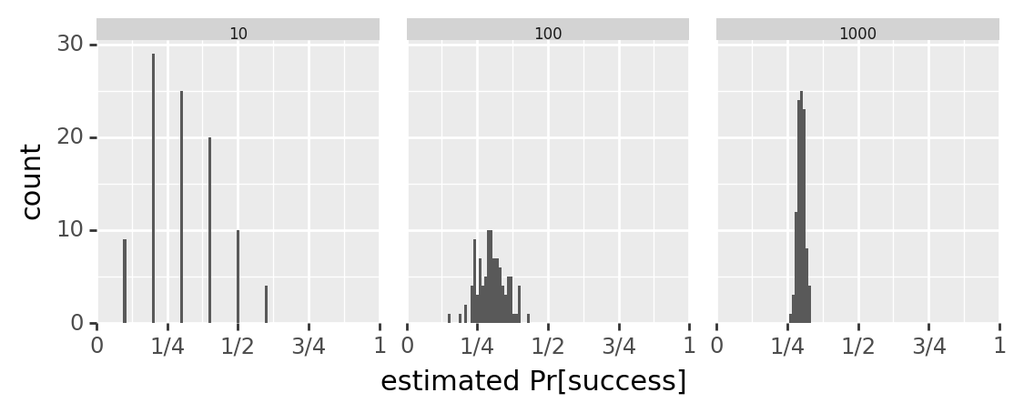

```python
np.random.seed(123)
ts = []
ps = []
theta = 0.3
M = 100 if DRAFT else 100_000
for N in [10, 100, 1_000]:
    data = {'N': N, 'theta': theta}
    sample = model.sample(data = data, seed = 123, chains = 1,
       iter_sampling = M, iter_warmup = 0, show_progress = False,
       show_console = False)
    y = sample.stan_variable('y')
    theta_hat = y / N
    ps.extend(theta_hat)
    ts.extend(itertools.repeat(N, M))
xlabel = 'estimated Pr[success]'
df = pd.DataFrame({xlabel: ps, 'trials': ts})
mydraw(pn.ggplot(df, pn.aes(x = xlabel))
  + pn.geom_histogram(binwidth=0.01)
  + pn.facet_grid('. ~ trials')
  + pn.scales.scale_x_continuous(limits = [0, 1], breaks = [0, 1/4, 1/2, 3/4, 1],
      labels = ["0", "1/4", "1/2", "3/4", "1"], expand=[0, 0])
  + pn.scales.scale_y_continuous(expand=[0, 0, 0.05, 0])
  + pn.theme(aspect_ratio = 1, panel_spacing = 0.15,
             strip_text = pn.element_text(size = 6),
             strip_background = pn.element_rect(height=0.08,
                                fill = "lightgray")))
```

## 3.2 Pseudorandom numbers

As a probabilistic programming language, Stan relies on random number generation. Because Stan runs on traditional digital computers (i.e., von Neumann machines), it cannot truly generate random numbers. Instead, it does the next best thing and uses a *pseudorandom number generator* (PRNG) to generate a sequence of numbers deterministically. Specifically, we set a random number generation *seed*, which when combined with a PRNG, generates a sequence of numbers deterministically that have many of the properties of truly random numbers. The (free online) book by Devroye (1986) is the definitive reference for pseudorandom number generation for statistical distributions and contains a general introduction to PRNGs.

We can see how random number generators work in Stan by running our sampling method with seeds 123, 19876, and 123.

```python
for seed in [123, 19876, 123]:
    sample = model.sample(data = data, seed = seed, chains = 1,
                          iter_sampling = 10, iter_warmup = 0,
                          show_progress = False, show_console = False)
    print(f"{seed = };  sample = {np.asarray(sample.stan_variable('y'), dtype=int)}")
```

```
seed = 123;  sample = [322 324 306 333 311 318 294 323 282 311]
seed = 19876;  sample = [286 303 286 309 289 276 317 298 328 294]
seed = 123;  sample = [322 324 306 333 311 318 294 323 282 311]
```

The two runs with seed 123 produce the same results. The code to extract values of `y` is clunky because the `stan_variable()` method always returns a floating point type and we have converted it to an integer-valued NumPy array.

Generally, we want our Stan programs to *replicate* similar results with different random seeds. Substantially different results from different seeds is a red flag that there is something wrong with the combination of model and data.

## 3.3 Monte Carlo integration

Bayesian computation relies on averaging over our uncertainty in estimating parameters. In general, it involves computing expectations, which are weighted averages with weights given by densities. In this section, we will introduce Monte Carlo methods for calculating a simple integral corresponding to the expectation of a discrete indicator variable. We’ll use the textbook example of throwing darts at a board randomly and using the random locations to estimate the mathematical constant $\pi$.

We start with a two-unit square centered at the origin. Then we will generate points uniformly at random in this square. For each point $(x, y)$, we will calculate whether it falls inside the unit circle circumscribed within the square, which is true if the distance to the origin is less than or equal to 1,
$$\sqrt{x^2 + y^2} \leq 1,$$
which simplifies by squaring both sides to
$$x^2 + y^2 \leq 1.$$
The proportion of such points gives the proportion of the square’s volume taken up by the circle. Because the square is $2 \times 2$, it has an area of 4, so the circle has an area of 4 times the proportion of points falling inside the circle (i.e., in the unit disc).

Here’s the Stan code.

```
stan/monte-carlo-pi.stan
```

```stan
generated quantities {
  real<lower=-1, upper=1> x = uniform_rng(-1, 1);
  real<lower=-1, upper=1> y = uniform_rng(-1, 1);
  int<lower=0, upper=1> inside = x^2 + y^2 < 1;
  real<lower=0, upper=4> pi = 4 * inside;
}
```

The program declares variables `x` and `y` and constrains them to fall in the interval $[-1, 1]$ and assigns them uniform random values. The indicator variable `inside` is set to 1 if the Euclidean length of the vector $\begin{bmatrix}x & y\end{bmatrix}$ is less than 1 (i.e., it falls within an inscribed unit circle) and is set to 0 otherwise. The We then set a variable `pi` equal to 4 times the indicator value. The mean of the sample for `pi` will be our estimate of $\pi$.

First, we compile and then sample from the model, taking a sample size of `M = 10_000` draws. Then we plot the draws.

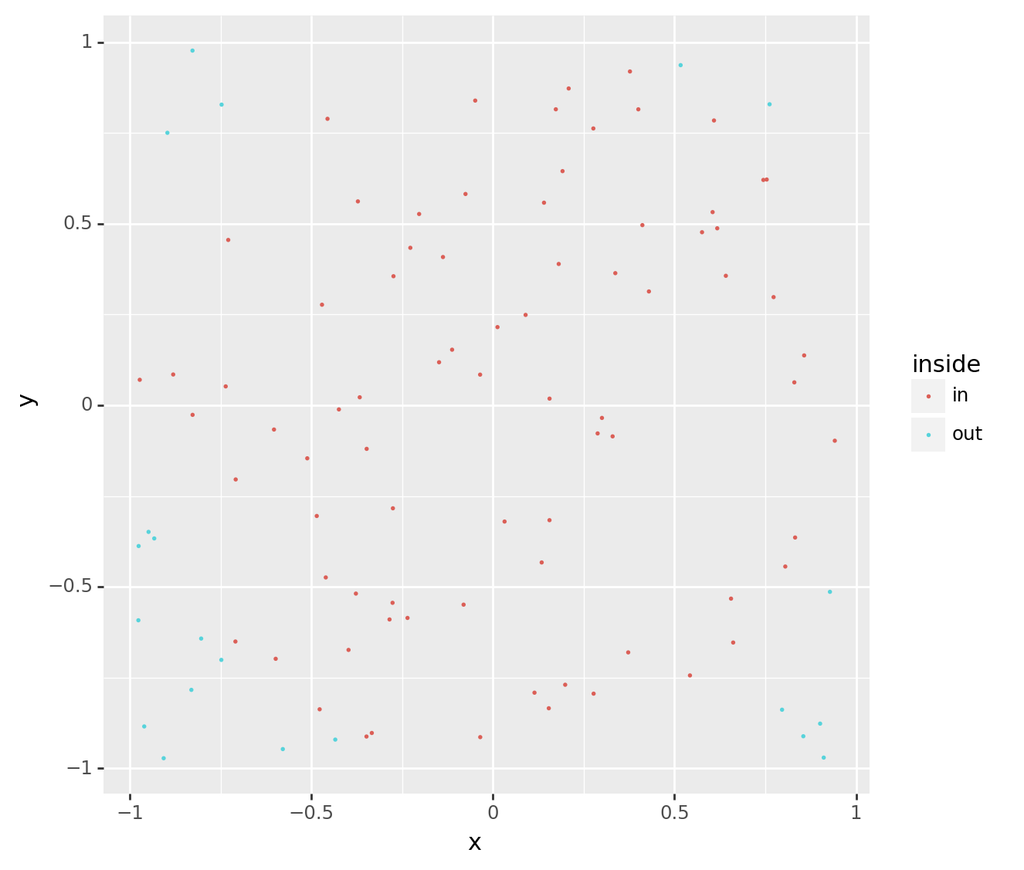

```python
M = 100 if DRAFT else 10_000
model = csp.CmdStanModel(stan_file = '../stan/monte-carlo-pi.stan')
sample = model.sample(chains = 1, iter_warmup = 0, iter_sampling = M,
                      show_progress = False, show_console = False,
                      seed = 123)
x_draws = sample.stan_variable('x')
y_draws = sample.stan_variable('y')
inside_draws = [int(i) for i in sample.stan_variable('inside')]
pi_draws = sample.stan_variable('pi')
inside_named_draws = np.array(["out", "in"])[inside_draws]
df = pd.DataFrame({'x': x_draws, 'y': y_draws,
                   'inside': inside_named_draws})
mydraw(
  pn.ggplot(df, pn.aes(x = 'x', y = 'y',
                group='inside', color='inside'))
  + pn.geom_point(size = 0.1)
  + pn.labs(x = 'x', y = 'y')
  + pn.coord_fixed(ratio = 1)
)
```

Next, we take the sample mean of the indicators for being inside the circle, which produces an estimate of the probability of a point being inside the circle. This corresponds directly to the expectation
$$\begin{align}
\mathbb{E}[4 \cdot \textrm{I}(\sqrt{X^2 + Y^2} \leq 1)]
&= \int_{-1}^1 \int_{-1}^1
\textrm{I}(x^2 + y^2 \leq 1) \cdot p(x, y) \, \textrm{d}x \, \textrm{d}y
\\[4pt]
&= \int_{-1}^1 \int_{-1}^1
\textrm{I}(x^2 + y^2 \leq 1) \cdot \textrm{uniform}(x \mid -2, 2)
\cdot \textrm{uniform}(y \mid -2, 2) \, \textrm{d}x \, \textrm{d}y
\\[4pt]
&= \int_{-1}^1 \int_{-1}^1
4 \cdot \textrm{I}(x^2 + y^2 \leq 1) \, \textrm{d}x \, \textrm{d}y
\\[4pt]
\pi.
\end{align}$$

The posterior mean `inside` is the probability that a random point in the 2-unit square falls in the inscribed unit circle. The posterior mean for `pi` is thus our estimate for $\pi$.

```python
Pr_is_inside = np.mean(inside_draws)
pi_hat = np.mean(pi_draws)
print(f"Pr[Y is inside circle] = {Pr_is_inside:.3f};")
print(f"estimate for pi = {pi_hat:.3f}")
```

```
Pr[Y is inside circle] = 0.790;
estimate for pi = 3.160
```

The true value of $\pi$ to 3 digits of accuracy is $3.142$, so we are close, but not exact, as is the nature of Monte Carlo methods. If we increase the number of draws, our error will go down. Theoretically, with enough draws, we can get any desired precision; in practice, we don’t have that long to wait and have to make do with only a few digits of accuracy in our Monte Carlo estimates. This is usually not a problem because statistical uncertainty still dominates our numerical imprecision in most applications; we discuss this important point later when contrasting estimation uncertainty and sampling uncertainty in the section on posterior predictive inference and when considering practical guidance on how long to run Stan.

### Random points are far away in high dimensions

Suppose we wanted to sample points in the unit disc? One thing we could do is sample points in the unit square until we draw one that is in the unit disc. In two dimensions, this is fairly efficient, with 79% of the points falling in the circle. But what will happen in higher dimensions? Let’s write some Stan code and see.

```
stan/unit-hypersphere.stan
```

```stan
data {
  int<lower=0> D;
}
transformed data {
  array[D] real one_D = rep_array(1, D);
}
generated quantities {
  array[D] real y = uniform_rng(-1, one_D));
  int<lower=0, upper=1> inside = norm2(y) < 1;
}
```

In this case, we take a natural number `D` as input for the dimensionality of the hypercube. We have introduced a block for transformed data, and declared a variable `one_D` to be a size `D` array of 1 values. The transformed data block is executed once as data is read in and its values are constant outside of the transformed data block. In the generated quantities block, we use the array of 1 values to assign `y` to an array of values, each of which is independently generated from a $\textrm{uniform}(-1, 1)$ distribution. This means `y` will be uniformly distributed within the hypercube $[-1, 1]^D$. The integer `inside` will be set to 1 if `y` falls within the unit hypersphere centered at the origin (i.e., circumscribed within the unit hypercube).

By construction, the distance from the origin to the side of the hypercube and hence the radius of the inscribed hypersphere remain constant at 1. In contrast, the distance from the origin to a corner is $\sqrt{D} = \sqrt{\underbrace{1 + 1 + \cdots 1}_{d \ \textrm{times}}$ in $D$ dimensions. Now let’s see what happens to the proportion of volume in the inscribed hypersphere as the dimensionality grows.

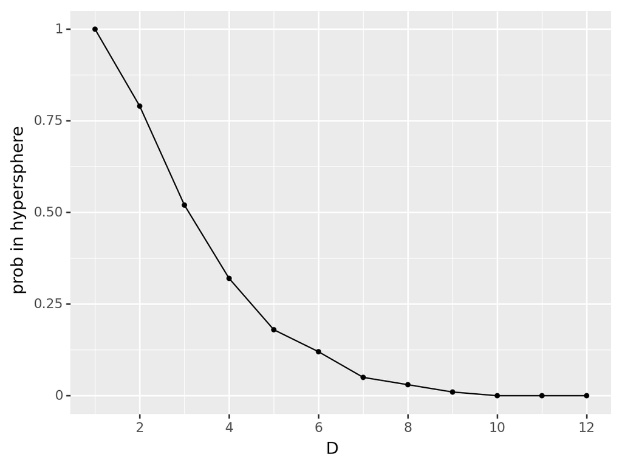

```python
M = 100 if DRAFT else 10_000
model = csp.CmdStanModel(stan_file = '../stan/unit-hypersphere.stan')
in_probs = np.repeat(1.0, 13)
for D in range(1, 13):
    sample = model.sample(chains=1, iter_warmup = 0, iter_sampling = M,
                          data = {'D' : D}, show_progress = False,
              show_console = False, seed = 123)
    inside_draws = sample.stan_variable('inside')
    in_probs[D] = np.sum(inside_draws) / M

mydraw(pn.ggplot(pd.DataFrame({'D':np.arange(1, 13), 'prob in hypersphere':in_probs[1:]}),
                 pn.aes(x = 'D', y='prob in hypersphere'))
       + pn.geom_line()
       + pn.geom_point(size=1)
       + pn.scale_x_continuous(breaks = [0, 2, 4, 6, 8, 10, 12]))
```

## 3.4 Markov chain Monte Carlo methods

In the previous sections, we generated a sample of draws by taking a sequence of independent draws. We then just averaged results to get plug-in estimates for expectations.

In modern applied Bayesian modeling, it is almost never possible to generate independent draws from the posterior distribution and apply pure Monte Carlo methods. The only case where it is possible is within the highly restrictive exponential family of sampling distributions with conjugate priors (Diaconis and Ylvisaker 1979). Before the MCMC revolution of the 1990s, Bayesian inference was largely restricted to conjugate priors. Even if the entire model wasn’t purely conjugate, conjugate priors remained popular due to the use of Gibbs sampling for MCMC, either hand-built or coded in in the first probabilistic programming language, BUGS (Lunn et al. 2012).

The introduction of automatic differentiation opened up the possibility of coding the more efficient and scalable Hamiltonian Monte Carlo method in Stan. This has led to the adoption of more non-conjugate priors and general priors.

In Markov chain Monte Carlo methods, we base each draw on the previous draw. A sequence of random variables each of which depends only on the previous variable generated is called a *Markov chain*. That is, a sequence of random variables $Y_1, Y_2, \ldots$ makes up a Markov chain if
$$p_{Y_{n+1} | Y_{1}, \ldots Y_N}(y_{n + 1} | y_1, \ldots, y_n)
=
p_{Y_{n+1} \mid Y_n}(y_{n+1} \mid y_n)$$

We can illustrate with a simple example of three Markov chains, all of which have a stationary distribution of $\textrm{bernoulli}(0.5)$ and thus the long-term average of all chains should approach 0.5. We will introduce a parameter $\theta \in (0, 1)$ and take the probabilities of element $Y_{n+1}$ depending on the previous element $Y_{n}$ to be
$$\begin{align}
\Pr[Y_{n + 1} &= 1 \mid Y_n = 1] = \theta
\\
\Pr[Y_{n + 1} &= 1 \mid Y_n = 0] = 1 - \theta
\end{align}$$
The first line says that if the last number we generated is 1, the probability of the next element being 1 is $\theta$. The second line says that if the last number we generated is 0, the probability of the next element being 1 is $1 - \theta$, and thus the probability of the next element being 0 is $\theta$. That is, there’s a probability of $\theta$ of generating the same element as the last element.

Here is a Stan program that generates the first $M$ entries of a Markov chain over outputs 0 and 1, with probability $\theta$ of generating the same output again.

```
stan/markov-autocorelation.stan
```

```stan
data {
  int<lower=0> M;
  real<lower=0, upper=1> rho;  // prob of staying in same state
}
generated quantities {
  array[M] int<lower=0, upper=1> y;  // Markov chain
  y[1] = bernoulli_rng(0.5);
  for (m in 2:M) {
    y[m] = bernoulli_rng(y[m - 1] ? rho : 1 - rho);
  }
}
```

The assignment to `y[m]` in this program is equivalent to this longer form.

```stan
    if (y[m - 1] == 1) {
      y[m] = bernoulli_rng(rho);
    } else {
      y[m] = bernoulli_rng(1 - rho);
    }
```

The more concise form exploits two features of Stan. First, boolean expressions are coded as `1` (true) or `0` (false) in Stan, like in C++ and Python. Because `y[m - 1]` is constrained to take on values 0 or 1, we know that `y[m - 1] == 1` is equivalent to `y[m - 1]`. Second, it uses the *ternary operator*, also like in C++. The expression `cond ? e1 : e2` involves three arguments, separated by a question mark (`?`) and a colon (`:`); it’s value is the value of `e1` if `cond` is true and the value of `e2` otherwise. Unlike an ordinary function, the ternary operator only evaluates `e1` if the condition is true and only evaluates `e2` if the condition is false.

We can simulate these models in Python and print the first 100 values simulated for the Markov chain $y$.

```python
model = csp.CmdStanModel(
               stan_file = '../stan/markov-autocorrelation.stan')
M = 100 if DRAFT else 1000
rhos = []
iterations = []
draws = []
estimates = []
for rho in [0.05, 0.5, 0.95]:
    data = {'M': M, 'rho': rho}
    sample = model.sample(data = data, seed = 123, chains = 1,
                      iter_warmup = 0, iter_sampling = 1,
                      show_progress = False, show_console = False)
    y_sim = sample.stan_variable('y')
    cum_sum = np.cumsum(y_sim)
    its = np.arange(1, M + 1)
    ests = cum_sum / its
    draws.extend(y_sim[0])
    iterations.extend(its)
    estimates.extend(ests)
    rhos.extend(itertools.repeat(str(rho), M))
df = pd.DataFrame({'draw': draws, 'iteration': iterations,
                   'estimate': estimates, 'rho': rhos})
rho05 = np.array(df.query('rho == "0.05"').head(100)['draw'], dtype = 'int')
rho50 = np.array(df.query('rho == "0.5"').head(100)['draw'], dtype = 'int')
rho95 = np.array(df.query('rho == "0.95"').head(100)['draw'], dtype = 'int')
print("Markov chain draw with probability rho of repeating last value:\n")
print("rho = 0.05:", rho05, "\n")
print("rho = 0.50:", rho50, "\n")
print("rho = 0.95:", rho95, "\n")
```

```
Markov chain draw with probability rho of repeating last value:

rho = 0.05: [0 1 0 1 0 1 0 1 0 1 0 1 0 1 0 1 0 1 0 1 0 1 0 1 0 1 0 1 0 1 0 1 0 1 0 1 0
 1 0 1 0 1 0 1 0 1 0 1 0 1 0 1 0 1 0 1 0 1 0 1 0 1 0 0 1 0 1 0 1 0 1 0 1 0
 1 0 1 0 1 0 0 1 0 1 0 1 0 1 0 1 0 1 0 1 0 1 0 1 0 1]

rho = 0.50: [0 0 1 0 1 0 0 0 1 0 0 1 1 0 1 0 1 1 0 0 0 0 0 0 0 1 1 1 1 1 0 0 0 0 0 1 0
 1 1 1 1 1 1 1 1 0 1 0 1 0 0 1 0 0 1 0 1 1 0 0 1 1 0 0 1 1 1 0 1 1 0 1 0 0
 0 1 0 1 1 1 0 1 0 1 1 1 1 1 0 1 0 1 0 1 0 0 0 1 0 0]

rho = 0.95: [0 0 0 0 0 0 0 0 0 0 0 0 0 0 0 0 0 0 0 0 0 0 0 0 0 0 0 0 0 0 0 0 0 0 0 0 0
 0 0 1 1 1 1 1 1 1 1 1 1 1 1 1 1 1 1 1 1 1 1 1 1 1 1 0 1 1 1 1 1 1 1 1 1 1
 1 1 1 1 1 1 0 1 1 1 1 1 1 1 0 0 0 0 0 0 0 0 0 0 0 0]
```

With a 0.05 probability of staying in the same state, the Markov chain exhibits strong anti-correlation in its draws, which tend to bounce back and forth between 0 and 1 almost every iteration. In contrast, the 0.95 probability of staying in the same state means the draws have long sequences of 0s and 1s. The 0.5 probability produces independent draws from the Markov chain and we see short runs of 0s and 1s.

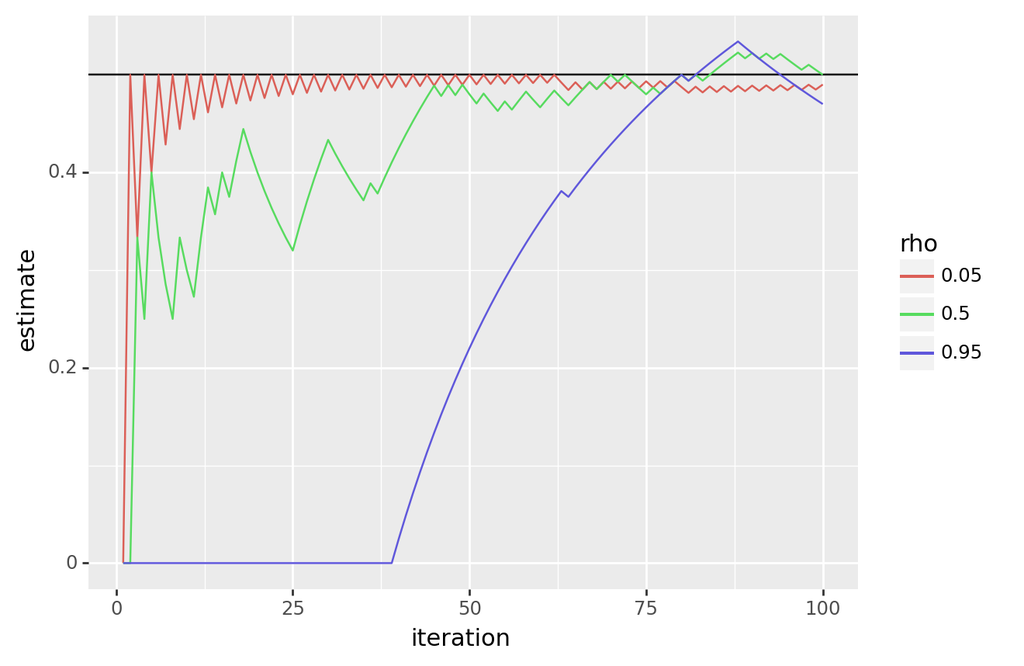

```python
mydraw(
    pn.ggplot(df, pn.aes(x='iteration', y='estimate',
                  group='rho', color='rho'))
    + pn.geom_hline(yintercept = 0.5, color = 'black')
    + pn.geom_line()
    + pn.labs(x = "iteration", y = "estimate")
)
```

The black horizontal line at 0.5 shows the true answer. It is clear that the anti-correlated chain (red) converges much more quickly to the true answer of 0.5 and more stably than the independent chain (green), which in turn converges much more quickly than the correlated chain (blue).

# 4 Hints for Python programmers

Python follows general programming language idioms like in C++ and Java, whereas Stan follows linear algebra idioms like in R and MATLAB.

## 4.1 Indexing from 1

Unlike Python, Stan uses the standard mathematical indexing for matrices, which is from 1. If I declare a `vector[3]`, then the valid indexes are 1, 2, and 3. If `v` is a vector variable, then `v[0]` is an indexing error and will throw an exception and log a warning as it is caught and the resulting MCMC proposal is rejected.

## 4.2 Storage order

Unlike Python, Stan uses a column-major memory layout for matrices. This means it’s more efficient to iterate by column than by row through a matrix. To visit every element of a matrix, you want to loop as follows.

```stan
matrix[M, N] x;  // M rows, N columns
for (n in 1:N) {
  for (m in 1:M) {
    ... operate on x[m, n] ...
  }
}
```

Arrays in Stan are stored in row-major order, but they are not stored in a single array like in NumPy’s `ndarray` type. Arrays of primitives store the primitive values in memory-local order. Arrays of containers store pointers to the containers. Thus accessing array members can be non-local in memory, but will not require copying. In contrast, accessing a row or column of a matrix usually requires allocating memory and copying.

## 4.3 Inclusive ranges

Unlike Python, Stan uses inclusive ranges, so that `1:3` represents the sequence 1, 2, 3. The main disadvantage of inclusive notation is that the length of `L:U` is `U - L + 1.`

Putting these together, Python loops over a container with `N` elements look as follows.

```python
v = np.random.rand(N)
for n in range(0, N):
    ... process v[n] ...
```

The Python version visits elements `v[0]`, `v[1]`, …, `v[N - 1].`

Loops in Stan are as follows.

```stan
vector[N] v;
for (n in 1:N) {
   ... process v[n] ...
}
```

The Stan version visits elements `v[1]`, `v[2]`, …, `v[N].`

## 4.4 Strong typing

Stan variables are strongly typed. This means every variable is assigned a type when it is declared and that type never changes. Only values of expressions of the same type of the variable may be assigned to it. Block variables are also sized and the size never changes after the declaration is executed.

There are three one dimensional (1D) real-valued container types (1D array, column vector, and row vector) and four two dimensional (2D) containers (2D array, 1D array of vectors, 1D array of column vectors, and matrix). There are functions to convert back and forth for common cases, but complicated cases must be handled manually. Loops that just do reassignment are fast in Stan as there is no overhead from derivative calculations; see the section on automatic differentiation for more details.

## 4.5 Block scope

Stan follows the C/C++ convention whereby variables declared within a block are local to that block. For example, in this Stan program, `logit_theta` is only a valid variable within the conditional block; once control has left the conditional block, `logit_theta` falls out of scope.

```stan
if (theta < 0.5) {
  real logit_theta = logit(theta);
  ...
}
logit_theta = 1.9; // ILLEGAL: OUT OF SCOPE
```

The solution is to move up the declaration.

```stan
real logit_theta;
if (theta < 0.5) {
  logit_theta = logit(theta);
  ...
}
logit_theta = 1.9;  // OK
```

## 4.6 Loops are not slow

Unlike in R and Python, loops are fast in Stan because Stan is a compiled language. For operations that only involve indexing and assignment, loops can be faster in Stan than their vectorized counterparts, because they avoid intermediate allocations.

However, this is only half of the story. Whenever functions are applied to parameters, the operation, its result, and its operands are recorded in an expression graph. For operations that involve functions other than indexing or reshaping operations applied to parameters, vectorized versions of functions will almost always reduce peak memory usage and increase speed.

## 4.7 Whitespace and semicolons

Stan follows C/C++ conventions on whitespace in which any sequence of whitespace characters (space, tab, new line) are interchangeable semantically. Python and R are both space-sensitive in different ways—Python uses space as a block delimiter and R has an eager line-based parser. In Stan, we use semicolons (`;`) to mark the end of an atomic statement. This means it is OK to continue expressions on the following line without any special syntactic marker, e.g.,

```stan
lp[k] = bernoulli_lpmf(k | theta)
        + normal_lpdf(y[n] | mu[k], sigma[k]);
```

Both R and Python here would try to terminate the assignment to `lp` after the first line and leave a dangling expression for the second line. We recommend following mathematical conventions and breaking a line before an operator, ideally right before a term in a chain of additions or a factor in a chain of multiplications.

# 5 Stan example: Laplace’s live birth inverse problem

Given a forward model that generates data from parameters, the *inverse problem* is that of *inferring* parameter values from observed data.

## 5.1 Bayesian solutions to inverse problems

Bayes (1763) introduced the paradigm of statistical inference that has come to be known as Bayesian statistics.

### Parametric statistics and variable types

Before introducing Bayes’s paradigm, we will try to settle on some terminology around variables. In Stan, we classify each variable as being a data variable or a parameter.

When talking about Bayesian statistics abstractly (i.e., without regard to a specific model form), we will use the variable $y$ to represent all of the model’s *data*, which are values that are known or observed. Data my include

- *constants*: sizes, bounds,
- *unmodeled data*: covariates (aka features), constant parameters of priors, and
- *modeled data*: outcome measurements, individual or group-level covariates in generative models.

Similarly, we us the variable $\theta$ for all of our model’s *parameters*, which are values that are not known and must be inferred. Parameters may include

- *process parameters*: parameters of the forward scientific process,
- *measurement parameters*: parameters of the measurement process,
- *hyperpriors*: hyperparameters for prior distributions,
- *missing data*: unknown data items, latent but potentially observable values, and
- *predictive quantities*: event probability indicators, predictions, forecasts, backcasts.

Constants are things like the sizes of matrices, the number of components in a mixture model, the bounds on a constrained variable, etc. Covariates are typically used as inputs (aka dependent variables) to a regression. For instance if I might want to predict someone’s presidential vote based on their income and state of residence. In this case, the income and state of residence are unmodeled covariates and the vote is modeled data if it is known.

In Stan, the number of parameters may depend on the data, but once the data $y$ is fixed, the number of parameters is also fixed. This means we can implement some *non-parametric* models (e.g., Gaussian processes), but have to approximate others (e.g., Dirichlet processes).

### The Bayesian process

Gelman et al. (2013) summarize the process of developing a Bayesian model for an applied problem as follows,

1. _Define a joint *probability model* over all of the observables and non-observables that is consistent with what we know about the underlying scientific process and underlying measurement process (which together form the data-generating process) and our prior knowledge.
2. *Condition on observed data* to infer the posterior distribution of any quantities of interest such as predictions or event probabilities.
3. *Evaluate the model* in terms of fit to data and resulting predictions, how sensitive the predictions are to model assumptions, and if necessary, go back to step (1) and refine the model.

Usually, the joint probability model here is defined in terms of a parametric *sampling density* $p(y \mid \theta)$ which is a *forward model* describing how to generate observations $y$ given parameters $\theta$, and a *prior density* $p(\theta)$ capturing what is known about the unknowns before observing the current data $y$.

Stan is useful for expressing the model (1), performing posterior inference (2), and evaluating and comparing models (3).

### Bayes’s formulation

Bayes (1763) formulated the inverse problem of determining a posterior distribution with density $p(\theta \mid y)$ from a prior with density $p(\theta)$ and a sampling distribution with density $p(y \mid \theta)$. Bayes provided the following derivation, which has come to be known as *Bayes’s rule*.
$$\begin{align}
p(\theta \mid y)
&= \frac{p(y, \theta)}
{p(y)}
& \textrm{[definition of conditional probability]}
\\[6pt]
&= \frac{p(y \mid \theta) \cdot p(\theta)}
{p(y)}
& \textrm{[chain rule]}
\\[6pt]
&= \frac{p(y \mid \theta) \cdot p(\theta)}
{\int_{\Theta} \, p(y, \theta) \, \textrm{d}\theta}
& \textrm{[law of total probability]}
\\[6pt]
&= \frac{p(y \mid \theta) \cdot p(\theta)}
{\int_{\Theta} \, p(y \mid \theta) \cdot p(\theta) \,
\textrm{d}\theta}.
& \textrm{[chain rule]}
\end{align}$$

The first steps reveal the key densities involved in Bayesian inference for data $y$ and parameters $\theta$,
$$\underbrace{p(\theta \mid y)}_{\textrm{posterior}}
=
\underbrace{p(y \mid \theta)}_{\textrm{likelihood}}
\cdot
\underbrace{p(\theta)}_{\textrm{prior}}
\ /
\underbrace{p(y)}_{\textrm{evidence}}.$$
When considered as a function of the parameter $\theta$ for fixed data $y$, as it is in Bayes’s rule, the density $p(y \mid \theta)$ is known as the *likelihood*.

The second step expresses the evidence in terms of the likelihood and prior.
$$p(y) = \int_{\Theta} p(y \mid \theta) \cdot p(\theta) \,
\textrm{d}\theta.$$
In applications, this integral is usually intractable in the sense of there being no closed-form analytic solution in terms of elementary functions. For example, even a simple logistic regression presents an intractable integral for the evidence, with
$$\begin{align}
p(\theta) &= \textrm{normal}(\theta, 1),
\\[2pt]
p(y \mid \theta, x) &= \prod_{n=1}^N \textrm{bernoulli}(y_n \mid
\textrm{logit}^{-1}(x_n \cdot \theta))
\end{align}$$

The good news is that most applications of Bayesian statistics do not require us to solve the integral presented in the denominator of Bayes’s rule, even numerically. One case where we need normalizing constants is to evaluate Bayes factors for model comparison, but like Gelman et al. (2013), we prefer other means of evaluating models like posterior predictive checks or cross-validation, both of which are beyond the scope of this getting-started tutorial.

Rather than computing the evidence, we work up to a proportion (i.e., a multiplicative constant), where we have
$$p(\theta \mid y) \propto p(y \mid \theta) \cdot p(\theta),$$
because $p(y)$ is a constant in the sense that it does not depend on $\theta$. This is what lets us express the log posterior as the sum of the log likelihood and the log prior in Stan,
$$\log p(\theta \mid y)
= \log p(y \mid \theta)
+ \log p(\theta)
+ \textrm{const},$$
where the constant is the negative log evidence, $- \log p(y)$.

## 5.2 Live birth data

A decade after Bayes published his rule, Pierre Simon Laplace (1774) used Euler’s *beta function* to derive the conjugate prior for binomially distributed data. A *conjugate prior* for a sampling distribution is a family of distributions such that if the prior is drawn from that family, the posterior will be, too. In this section, we will work through Laplace’s analysis in what has become the standard textbook introduction to Bayesian inference.

Laplace gathered data on the sexes of babies in live births in Paris between 1745 and 1770.

Live births in Paris between 1745 and 1770.

| sex | live births |
| --- | --- |
| female | 105,287 |
| male | 110,312 |

It sure looks like there were more boys than girls born.

## 5.3 Laplace’s model

With $y$ male births out of $N$ total births, Laplace adopted the sampling distribution
$$y \sim \textrm{binomial}(N, \theta),$$
which requires a number of trials $N \in \mathbb{N}$, chance of success $\theta \in (0, 1)$, and number of successes $y \in 0{:}N$.

Laplace used the prior
$$\theta \sim \textrm{beta}(1, 1),$$
where
$$\textrm{beta}(\theta \mid \alpha, \beta)
\propto \theta^{\alpha - 1} \cdot (1 - \theta)^{\beta - 1}.$$
for $\alpha, \beta \in (0, \infty)$, and $\theta \in (0, 1)$. The distribution $\textrm{beta}(1, 1)$ is uniform over probabilities $\theta \in (0, 1)$ because the density is proportional to a constant,
$$\begin{align}
\textrm{beta}(\theta \mid 1, 1)
&\propto \theta^{1 - 1} \cdot (1 - \theta)^{1 - 1}
\\[4pt]
&= 1.
\end{align}$$

### Analytic posterior

As an aside, Laplace’s model here is simple enough to solve for the posterior analytically.
$$\begin{align}
p(\theta \mid y, N)
&\propto p(y \mid N, \theta) \cdot p(\theta)
\\[4pt]
&= \textrm{binomial}(y \mid N, \theta)
\cdot \textrm{beta}(\theta \mid 1, 1)
\\[4pt]
&\propto \theta^y \cdot (1 - \theta)^{N - y} \cdot \theta^{1 - 1} \cdot (1
- \theta)^{1 - 1}
\\[4pt]
&= \theta^{y + 1} \cdot (1 - \theta)^{N - y + 1}
\\[4pt]
&\propto \textrm{beta}(\theta \mid y + 1, N - y + 1).
\end{align}$$
Despite the intermediate proportional-to steps, the normalizing constant is unique, so we can conclude that
$$p(\theta \mid y, N) = \textrm{beta}(\theta \mid y + 1, N - y + 1).$$
This entire derivation went through without ever worrying about the normalizing constant for the beta distribution or the binomial distribution.

## 5.4 Stan program for birth data

Unlike the first Stan model we saw, which only generates data, the following Stan program requires data to be provided, specifically the the number of male births ($y$) and the total number of births ($N$). The model will then allow us to estimate the probability of a male birth ($\theta$) as well as the probability that boys are more likely to be born than girls ($\theta > 0.5$). The Stan program for Laplace’s model is as follows.

```
stan/sex-ratio.stan
```

```stan
data {
  int<lower = 0> N;  // number of live births
  int<lower = 0, upper = N> y;  // male births
}
parameters {
  real<lower=0, upper=1> theta;  // chance of boy
}
model {
  theta ~ beta(1, 1);  // prior
  y ~ binomial(N, theta);  // binomial sampling
}
generated quantities {
  int<lower=0, upper=1> boys_gt_girls = theta > 0.5;
}
```

## 5.5 Parameter and model blocks

In this Stan program, we see that both the number of total births $N$ and the number of male births $y$ are given as data. Then there are two additional blocks we did not see in our earlier program, a *parameters block*, which is used to declare unknown values (here, just the male birth rate $\theta$), and a *model block*, which is where we define our target log density up to an additive constant. The target log density is typically a Bayesian posterior expressed as a log prior and log sampling distribution. The parameters block declares the type of `theta`, which is a real value constrained to fall in the interval $[0, 1]$. The model block defines the prior, which we take to be uniform over the possible values for `theta.` The model block also defines the sampling distribution, which codes the fact that the observed data `y` was generated from a binomial distribution with `N` trials and `theta` probability of a male birth. Finally, we have a generated quantities block that defines a single binary indicator variable, `boys_gt_girls.` This variable will take the value 1 if the probability of a boy is greater than the probability of a girl.

## 5.6 Sampling from the posterior

When we run a Stan program, Stan generates a sequence of $M$ random draws, which are approximately identically distributed according to the posterior,
$$\theta^{(1)}, \ldots, \theta^{(M)} \sim p(\theta \mid y).$$
If we were to take $M \rightarrow \infty$, the draws will converge to being identically drawn from the posterior. In simple or well behaved models, coupling arguments show that they converge to true draws from the posterior in hundreds or thousands (or sometimes more) draws (Jacob, O’Leary, and Atchadé 2020); they become numerically indistinguishable from true draws well before that time.

### Stan’s sampler

Stan uses a *Markov chain Monte Carlo* (MCMC) algorithm, which can lead to autocorrelation in the random draws from the posterior. That is, the draws are not typically independent, with each draw being correlated (or anti-correlated) with the previous draw. This autocorrelation does not introduce bias into the Monte Carlo estimates.

In order to scale to high dimensional problems, we need to exploit gradients and/or Hessians. Duane et al. (1987) introduced the gradient-based Hamiltonian Monte Carlo (HMC) algorithm; the overview by Neal (2011) discusses theoretical and practical scaling results and Livingstone et al. (2019) provide geometric ergodicity results.

For Stan, Hoffman and Gelman (2014) developed an adaptive form of Hamiltonian Monte Carlo (HMC) known as the no-U-turn sampler (NUTS), and Betancourt (2017a) improved it with an adaptive preconditioner and multinomial sampling over trajectories. NUTS can be hyper-efficient in the sense of generating anti-correlated draws that can lead to more efficient Monte Carlo estimates than independent draws.

### Fitting in Stan

We fit Laplace’s model by compiling the model, constructing a dictionary for the data, and then calling the `sample` method on the compiled model with the dictionary. We call the sample method with 1,000 warmup iterations and 10,000 sampling iterations; we are taking so many draws in order to draw show smooth plots later. The Stan programs considered in this introduction are all quite simple and inexpensive to run for many iterations. We consider how many draws are required for statistical inference in the section on practical guidelines.

```python
model = csp.CmdStanModel(stan_file = '../stan/sex-ratio.stan')
boys = 110312
girls = 105287
data = {'N': boys + girls, 'y': boys}
M = 100 if DRAFT else 10_000
sample = model.sample(data = data, seed = 123,
                      iter_sampling = M, iter_warmup = 1000,
                      show_progress = False, show_console = False)
```

As before, we proceed by first extracting the draws for the variables `theta` and `boys_gt_girls.`

```python
theta_draws = sample.stan_variable('theta')
boys_gt_girls_draws = sample.stan_variable('boys_gt_girls')
```

We can plot a histogram of approximate draws $\theta^{(m)} \sim p(\theta \mid N, y)$ from the posterior to give us a sense of the value of $\theta$ and its uncertainty given our observed data $y$.

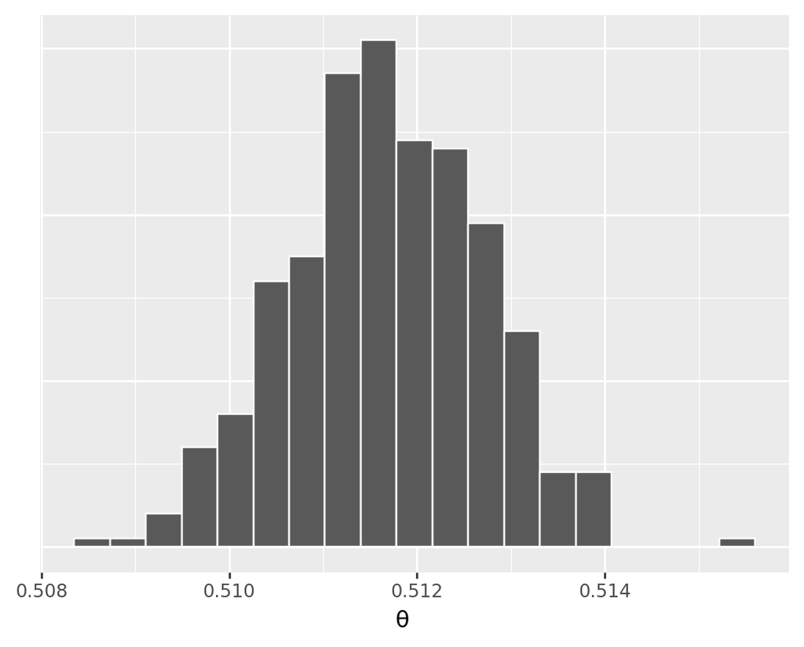

```python
mydraw(
  pn.ggplot(pd.DataFrame({'theta': theta_draws}),
            pn.aes(x = 'theta')) +
  pn.geom_histogram(color='white') +
  pn.labs(x = 'θ') +
  pn.theme(axis_text_y = pn.element_blank(),
           axis_title_y = pn.element_blank(),
           axis_ticks_major_y = pn.element_blank())
)
```

All of the draws have a value for $\theta$ between 0.50 and 0.52. In the next sections, we will see how to use these draws to estimate a single value for $\theta$ as well as to compute probabilities, such as the probability that $\theta > 0.5$ or $\theta > 0.51$.

## 5.7 Bayesian point estimates

In Bayesian terms, a *point estimate* for a parameter $\Theta$ conditioned on some observed data $Y = y$ is a single value $\hat{\theta} \in \mathbb{R}^D$ that in some way summarizes the posterior $p(\theta \mid y)$. Formally, Bayesian estimators are defined in such a way as to minimize a *loss function*.

### Posterior mean estimator

The most common Bayesian point estimate for a parameter is the posterior mean,

$$\begin{align}
\widehat{\theta}
&= \mathbb{E}[\Theta \mid Y = y]
\\[6pt]
&= \int_{\Theta} \theta \cdot p(\theta \mid y) \, \textrm{d}\theta
\\[6pt]
&= \lim_{M \rightarrow \infty} \, \frac{1}{M} \sum_{m=1}^M \theta^{(m)}
\\[6pt]
&\approx \frac{1}{M} \sum_{m=1}^M \theta^{(m)},
\end{align}$$
where in the last two lines, each draw is distributed approximately according to the posterior,
$$\theta^{(m)} \sim p(\theta \mid y).$$

We have snuck in conditional *expectation* notation in the first line of this definition. Expectations are just weighted averages, with weights given by a probability density. Bayesian inference involves expectations over the posterior, the concise notation for which is *conditional expectation* notation,
$$\mathbb{E}\!
\left[ f(\Theta) \mid Y = y \right]
\ = \
\int_{\Theta} f(\theta) \cdot p_{\Theta \mid Y}(\theta \mid y) \, \textrm d\theta,$$
where $\Theta$ and $Y$ are random variables with realizations $\theta \in \Theta$ and $y \in Y$ (we write $y \in Y$ for a random variable $Y$ if $y$ is in support of $Y$’s density, i.e., $p_Y(y) > 0$).

For Laplace’s model, the estimate for the male birth rate $\theta$ conditioned on the birth data $y$ is calculated as the sample mean for the extracted draws for `theta.`

```python
theta_hat = np.mean(theta_draws)
print(f"estimated theta = {theta_hat:.3f}")
```

```
estimated theta = 0.512
```

### Posterior median estimator, quantiles, and intervals

A popular alternative Bayesian point estimate is the *posterior median*, $\theta^+$. The median is such that for each dimension $d \in 1{:}D$,
$$\Pr[\Theta_d \leq \theta^+_d] = \frac{1}{2}.$$

The posterior median can be calculated by taking the posterior median of the draws, as follows.

```python
theta_plus = np.median(theta_draws)
print(f"estimated (median) theta = {theta_plus:.3f}")
```

```
estimated (median) theta = 0.512
```

Because our posterior distribution is nearly symmetric with Laplace’s data, the posterior mean and posterior median are very close.

#### Quantiles

```python
quantile_05 = np.quantile(theta_draws, 0.025)
quantile_95 = np.quantile(theta_draws, 0.975)
print(f"""0.05 quantile = {quantile_05:.3f};
0.95 quantile = {quantile_95:.3f}""")
```

```
0.05 quantile = 0.510;
0.95 quantile = 0.514
```

#### Posterior intervals

```python
print(f"central 90% posterior interval for theta")
print(f"    = ({quantile_05:.3f}, {quantile_95:.3f})")
```

```
central 90% posterior interval for theta
    = (0.510, 0.514)
```

Other intervals are computed in the exact same way.

### Estimation error and bias

The *error* of an estimate is its difference from the true value,
$$\textrm{err} = \hat{\theta} - \theta.$$
Our estimate $\hat{\theta}$ is implicitly a function of the data $y$ and so is $\textrm{err}$, so we can make this explicit and write
$$\textrm{err}(y) = \hat{\theta}(y) - \theta.$$

The *bias* of an estimator is defined as its expected error (as averaged over the data distribution for the random variable $Y$),
$$\begin{align}
\textrm{bias}
&= \mathbb{E}[\textrm{err}(Y)]
\\[6pt]
&= \mathbb{E}[\hat{\theta}(Y) - \theta]
\\[6pt]
&= \int_Y \hat{\theta}(y) - \theta \ \textrm{d}y.
\end{align}$$

### Properties of estimators

The posterior mean is a popular Bayesian estimator for two reasons. First, it is an *unbiased* estimator in the sense of having zero bias. Second, it has the minimum expected square error among unbiased estimators, where the *squared error* of an estimate is defined by
$$\textrm{err}^2(y) = \left(\hat{\theta}(y) - \theta\right)^2.$$
Posterior means might not exist if the posterior has very wide tails, like the standard Cauchy distribution, $\textrm{cauchy}(x \mid 0, 1) \propto \frac{1}{1 + x^2}$.

The posterior median $\theta^+$ has three pleasant properties. First, it is always well defined, even for densities with poles or very wide tails. Second, it is more robust to outliers than squared error because errors are not amplified by squaring. Third, the posterior median estimator minimizes expected absolute error.

The posterior mode may not exist. For example, there is no posterior mode in standard hierarchical models. There is not even a mode for a simple density with a pole, such as $\textrm{exponential}(x \mid 1) = \exp(-x)$ for $x > 0$. The posterior mode is at least consistent in the sense of converging to the true value as the data size grows in cases where it exists.

We will concentrate on posterior means in this quick introduction to Bayes and Stan.

### (Markov chain) Monte Carlo error and effective sample size

The Markov chain we use to sample is itself a random variable. Re-running the sampler will produce slightly different results due to Monte Carlo error (the error introduced by using only a finite sample of $M$ draws).

$$\begin{align}
\textrm{var}\left[\Theta_d \mid Y = y\right]
&= \mathbb{E}\left[\left(\Theta_d - \mathbb{E}\left[\Theta_d \mid Y = y\right]\right)^2
\ \big| \ Y = y\right]
\\[6pt]
\textrm{sd}\left[\Theta_d \mid Y = y\right]
&= \sqrt{\textrm{var}[\Theta_d \mid Y = y]}.
\end{align}$$

## 5.8 Estimating event probabilities

Laplace wasn’t looking for a point estimate for $\theta$. He wanted to know the probability that $\theta > \frac{1}{2}$ after observing $y$ male births in $N$ trials. In the notation of probability theory, he wanted to estimate an event probability.

A subset of parameters is known as an *event*. We can convert conditions on parameters into events. For example, the condition $\theta > \frac{1}{2}$ can be turned into the event
$$A = \left\{ \theta \in \Theta : \theta > \frac{1}{2} \right\}.$$
Events are what are assigned probabilities by a *measure* in probability theory. Given a probability measure, the probability of the event $A$, that the rate of boy births is higher than girl births, will be well defined. Because we can convert conditions to events, we will be sloppy and treat the conditions as if they were events. This allows us to write $\Pr\!\left[\Theta > \frac{1}{2} \, \big| \, N, y\right]$ for the probability of the event $\Theta > \frac{1}{2}$.

### Event probabilities via indicators

The *indicator function* $\textrm{I}$ maps propositions into the value 1 if they are true and 0 if they are false. For example, $\textrm{I}(\theta > \frac{1}{2}) = 1$ if the proposition $\theta > \frac{1}{2}$ is true, i.e., when $\theta$ is greater than one half.

*Event probabilities* are defined as posterior conditional expectations of indicator functions for events.
$$\begin{align}
\Pr[\Theta > 0.5 \mid N, y]
&= \mathbb{E}\!\left[\textrm{I}[\Theta > 0.5] \,\big|\, N, y\right]
\\[8pt]
&= \int_{\Theta} \textrm{I}(\theta > 0.5) \cdot p(\theta \mid N, y) \, \textrm{d}\theta
\\[8pt]
&\approx \frac{1}{M} \sum_{m=1}^M \textrm{I}(\theta^{(m)} > 0.5),
\end{align}$$
where we assume $\theta^{(m)} \sim p(\theta \mid N, y)$ is distributed according to the posterior for $m \in 1{:}M$. Following physics conventions, we use square brackets for functors (functions that apply to functions); that means we write $\textrm{I}[\cdot]$ when we apply the indicator function to a random variable and $\textrm{I}(\cdot)$ when we apply it to a primitive scalar.

### Events as indicators in Stan

In Stan, we code the value of the indicator function directly and assign it to a variable in the generated quantities block.

```stan
generated quantities {
  int<lower=0, upper=1> boys_gt_girls = theta > 0.5;
}
```

Conditional expressions like `theta > 0.5` take on the value 1 if they are true and 0 if they are false. In mathematical notation, we would write $\textrm{I}(\theta > 0.5)$, which takes on value 1 if $\theta > 0.5$ and 0 otherwise; in Stan, like in C++, we treat `>` as a binary operator that returns either 0 or 1, so we just write `theta > 0.5` in Stan.

### The answer to Laplace’s question

The posterior mean of the variable `boys_gt_girls` is thus our estimate for $\Pr[\theta > 0.5 \mid N, y]$. It is essentially 1. Printing to 15 decimal places, we see

```python
Pr_boy_gt_girl = np.mean(boys_gt_girls_draws)
print(f"estimated Pr[boy more likely] = {Pr_boy_gt_girl:.15f}")
```

```
estimated Pr[boy more likely] = 1.000000000000000
```

The value of 1 returned as an estimate brings up the important problem of numerical precision. As we can see from the histogram, all of our sampled values for $\theta$ are greater than $\frac{1}{2}$.

Laplace calculated the result analytically, which is
$$\Pr\!\left[\Theta > \frac{1}{2} \ \bigg| \ N, y\right] \approx 1 - 10^{-27}.$$
Thus we would need an astronomical number of posterior draws before we would generate a value of $\theta$ less than $\frac{1}{2}$. As given, the answer of 1.0 is very close to the true answer and well within our expected Monte Carlo error. As an aside, using the standard double-precision (8 byte, 64 bit) floating point representation for real numbers, the number $1 - 10^{-27}$ will round to $1$ because *machine precision*, which is defined as the largest $\epsilon$ such that $1 - \epsilon \neq 1$, is about $10^{-16}$. Let’s try it in Python, which, like Stan, uses double-precision arithmetic by default.

```python
print(f"{(1.0 == (1.0 - 1e-27)) = }")
```

```
(1.0 == (1.0 - 1e-27)) = True
```

which one would expect given $10^{-27}$ is below the machine precision,

```python
print(f"Machine precision: {np.finfo(float).eps}")
```

```
Machine precision: 2.220446049250313e-16
```

### MCMC summary statistics from Stan

With Stan, we can print a summary for the variable $\theta$ in the posterior, which reports all of these values. We just call The `.summary()` function on the sample.

```python
sample.summary(sig_figs = 3)
```

|  | Mean | MCSE | StdDev | 5% | 50% | 95% | N_Eff | N_Eff/s | R_hat |
| --- | --- | --- | --- | --- | --- | --- | --- | --- | --- |
| lp__ | -149000.000 | 0.036200 | 6.030000e-01 | -149000.00 | -149000.000 | -149000.000 | 277.0 | 69400.0 | 1.00 |
| theta | 0.512 | 0.000074 | 1.030000e-03 | 0.51 | 0.512 | 0.513 | 196.0 | 48900.0 | 1.01 |
| boys_gt_girls | 1.000 | NaN | 6.670000e-16 | 1.00 | 1.000 | 1.000 | NaN | NaN | NaN |

The rows are for our random variables, with `lp__` indicating the unnormalized log density defined by the Stan program. The unnormalized log density includes any change-of-variables adjustments required for transforming constrained parameters; the transforms for constrained parameters and associated change-of-variables adjustments are detailed in (Stan Development Team 2023b).

The other two rows are for variables defined in the Stan program, `theta`, and `boys_gt_girls.` The number of significant figures used in the results can be controlled in the summary function, as can the quantiles being reported.

# 6 Warmup and convergence monitoring

When running Markov chains, we want to make sure that we have moved far enough that our draws are approximately from the posterior. A standard way to monitor convergence is to start multiple Markov chains at different initializations (ideally chosen from a diffuse initialization like a draw from the prior) and measure whether they are producing draws from the same distribution.

## 6.1 Warmup

During its initial warmup iterations, Stan tries to find the high probability mass region in which it should be sampling, adapt a good step size, and estimate posterior variance. The variance is used to *precondition* the sampler through scaling; see (Neal 2011) for details. Stan can also estimate a dense covariance matrix and precondition with rotation and scaling (i.e., with a Euclidean metric).

Warmup converges when the step size and posterior covariance estimates no longer change. With multiple chains, it’s possible to test that they have all converged to roughly the same step size and covariance estimate. Unless things are going wrong, we typically don’t bother measuring whether adaptation has converged and instead measure our end goal directly, which is whether we are getting reasonable posterior draws after warmup.

Warmup doesn’t form a single coherent Markov chain because it uses memory to adapt. Once Stan starts sampling, the result is a Markov chain. All of our posterior analysis will be with draws from the Markov chain, not from warmup. We can save and extract the warmup draws to investigate the behavior of warmup.

## 6.2 Potential scale reduction and $\widehat{R}$

Stan uses the *potential scale reduction* statistic $\widehat{R}$ (pronounced “R hat”). Given a sequence of Markov chains, Stan splits each of them in half to make sure the first half and second half of the chain agree, then calculates variances within each chain and across all chains and compares. The statistic $\widehat{R}$ converges to 1 as the Markov chains converge to the same distributions.

## 6.3 How many chains for how long?

A simple rule of thumb is to run four chains until $\hat{R} \leq 1.01$ and effective sample size (ESS) is greater than 100. The reason we recommend an effective sample size of “only” 100 is that it means the standard error will be $\frac{1}{10}$ the size of the standard deviation. Given that posterior standard deviation represents residual uncertainty, calculating means to higher precision is rarely worthwhile.

The easiest way to achieve $\widehat{R} \leq 1.01$ and $N^{\textrm{eff}} > 100$ is to start with 100 warmup iterations and 100 sampling iterations. If there are $\widehat{R}$ values that are too large or there are effective sample size values that are too low, then double the number of sampling and warmup iterations, and try again. Running more warmup iterations is important because sampling will not be efficient if warmup has not converged. At most, using the same number of warmup and sampling iterations costs a factor of two over the optimal settings, which are not known in advance.

Even if we use more than four chains, we need to make sure that our effective sample size is at least 25 per chain. It is not that we need so many draws for inference, but that we do not trust our effective sample size estimator if it is much lower. One way to check that the ESS estimator is OK is to double the number of draws and make sure that the ESS also doubles. If it doesn’t, it’s a sign that the first ESS estimate is unreliable.

# 7 Stan example: A/B testing

A common application of statistics is to compare two things, such as the effectiveness of a new drug versus the current drug used to treat a condition. Another application might compare the effectiveness of two different advertisement presentations in getting users to click through. This is usually called *A/B testing* in a nod to comparing a hypothetical option A and option B.

Let’s consider three good Mexican restaurants in New York City, Downtown Bakery II in the East Village, Taqueria Gramercy in Gramercy, and La Delicias Mexicanas in Spanish Harlem. Here’s the number of reviews and 5-star reviews for these restaurants on the web site Yelp.

| name | 5-star reviews | total reviews |
| --- | --- | --- |
| Downtown Bakery II | 141 | 276 |
| Taqueria Gramercy | 84 | 143 |
| La Delicias Mexicanas | 41 | 87 |

We can estimate a few things. First, we can estimate the probability that each restaurant really is a 5-star restaurant. We will parameterize this directly with a rate of 5-star reviews parameter for each restaurant. Then we can rank the restaurants based on their probability of being a 5-star restaurant. What does it mean to “be a 5-star restaurant” in this sense? It means getting 5-star reviews from Yelp reviewers. Our model is going to treat the reviewers as *exchangeable* in the sense that we don’t know anything to distinguish them from one another. Now whether this notion of 5-star restaurant is useful will depend on how similar the reader is to the population of reviewers.

We will assume that the number of 5-star reviews for a restaurant $k \in 1{:}K$ depends on its underlying quality $\theta_k \in [0, 1]$,
$$n_k \sim \textrm{binomial}(N_k, \theta).$$
Here $N_k \in \mathbb{N}$ is the number of reviews for restaurant $k$ and $n_k \in 0{:}N_k$ the number of 5-star reviews. We further assume the probabilities of 5-star reviews have a beta distribution,
$$\theta_k \sim \textrm{beta}(\alpha, \beta).$$
In a beta distribution, the sum $\alpha + \beta$ determines how much to regularize estimates toward $\alpha / (\alpha + \beta)$, with $\alpha = \beta = 1$ providing a uniform distribution.

For inference, we will be interested in the posterior distribution $p(\theta \mid N, n)$ of 5-star review probabilities. This gives us the posterior density of the restaurants’ probability of receiving a 5-star review. With this posterior, we can rank restaurants based on their probability of receiving a 5-star review and calculate the probability that each is the best restaurant,
$$\Pr[\Theta_k = \max(\Theta) \mid n, N].$$

## 7.1 Stan model for A/B testing

We will assume there are a total of $K$ items being compared. In traditional A/B testing, $K = 2$, but our example uses $K = 3$ and our code works for any $K$. We define the indicator array for our event probability estimates in the generated quantities block.

```
stan/ab-test.stan
```

```stan
data {
  int<lower=0> K;
  array[K] int<lower=0> trials;
  array[K] int<lower=0> successes;
  real<lower=0> alpha;
  real<lower=0> beta;
}
parameters {
  array[K] real<lower=0, upper=1> theta;
}
model {
  successes ~ binomial(trials, theta);
  theta ~ beta(alpha, beta);
}
generated quantities {
  array[K] int<lower=0, upper=1> is_best;
  for (k in 1:K) {
    is_best[k] = theta[k] == max(theta);
  }
}
```

We have coded the data for $K$ items directly in terms of number of trials and number of successes. We have also supplied the prior for the probabilities of success as data as `alpha` and `beta.` The model is the same binomial as we had before, except now the likelihood and priors are vectorized. In general, Stan is able to take something like the binomial distribution, which has an integer number of trials, integer number of successes, and a scalar success probability and take vectors for all of these. What we have written above is identical to what we would get with a loop,

```stan
  for (k in 1:K) {
    successes[k] ~ binomial(trials[k], theta[k])
  }
```

The vectorization of `theta` is different in that only `theta` is an array, whereas `alpha` and `beta` are scalars. The sampling statement for `theta` is equivalent to

```stan
  for (k in 1:K) {
    theta[k] ~ beta(alpha, beta);
  }
```

Because `alpha` and `beta` are scalars, they are not indexed. Rather, they are *broadcast*, meaning that the same `alpha` and `beta` is reused for each dimension of `theta.`

So now let’s call and fit this model and print the summary. We are setting $\alpha = \beta = 2$, which is equivalent to setting them equal to 1 and adding 2 trials and 1 success to the data for each restaurant.

```python
M = 100 if DRAFT else 1000
model = csp.CmdStanModel(stan_file = '../stan/ab-test.stan')
data = {'K': 3, 'trials': [276, 143, 87],
        'successes': [141, 84, 41],
        'alpha': 2, 'beta': 2}
sample = model.sample(data = data, seed = 123,
                      iter_warmup = M, iter_sampling = M,
                      show_progress = False, show_console = False)
sample.summary(sig_figs = 2)
```

|  | Mean | MCSE | StdDev | 5% | 50% | 95% | N_Eff | N_Eff/s | R_hat |
| --- | --- | --- | --- | --- | --- | --- | --- | --- | --- |
| lp__ | -360.000 | 0.0880 | 1.200 | -360.00 | -360.00 | -360.00 | 180.0 | 45000.0 | 1.00 |
| theta[1] | 0.510 | 0.0013 | 0.031 | 0.46 | 0.51 | 0.56 | 543.0 | 135749.0 | 0.99 |
| theta[2] | 0.590 | 0.0021 | 0.040 | 0.53 | 0.59 | 0.66 | 377.0 | 94242.0 | 1.00 |
| theta[3] | 0.470 | 0.0027 | 0.046 | 0.39 | 0.47 | 0.55 | 285.0 | 71215.0 | 0.99 |
| is_best[1] | 0.048 | 0.0120 | 0.210 | 0.00 | 0.00 | 0.00 | 302.0 | 75504.0 | 1.00 |
| is_best[2] | 0.940 | 0.0140 | 0.250 | 0.00 | 1.00 | 1.00 | 315.0 | 78819.0 | 1.00 |
| is_best[3] | 0.018 | NaN | 0.130 | 0.00 | 0.00 | 0.00 | NaN | NaN | NaN |

# 8 Stan’s execution model

Stan programs consist of several blocks. Here is a summary of the blocks, when they are executed, and what they do. None of the blocks are required, but the blocks that do appear must be in the order listed here.

| *block* | *executed* | *behavior* |
| --- | --- | --- |
| `functions` | as needed | user-defined function definitions |
| `data` | once | read data to construct model |
| `transformed data` | once | define transformed data |
| `parameters` | once / log density | constrain parameters (w. Jacobian) |
| `transformed parameters` | once / log density | define transformed parameters |
| `model` | once / log density | evaluate model log density |
| `generated quantities` | once / draw | define generated quantities |

## 8.1 Data and transformed data

The *data* block contains only variable declarations. The variables declared in the data block are read once at data load time.

The *transformed data* block contains variable declarations and definitions. It is executed once, after the data is read is in, to define the transformed data variables. It defines functions of the data, such as standardized predictors, constants to use for priors, etc. The transformed data block may use pseudorandom number generation.

All variable declarations at the block level must declare types and sizes (which may be data dependent). Local variables within blocks are declared without sizes.

Constraints in the data block are evaluated at the end of the block’s execution. Any violations throw exceptions which terminate execution.

Transformed data variables may be assigned in the transformed data block, but after these blocks have executed, the variables may not be reassigned.

## 8.2 Parameters and transformed parameters

The *parameters* block declare the variables over which the model is defined. It contains only variable declarations with sizes. When executed, it is supplied with concrete parameter values, which it transforms to the unconstrained scale based on the declared constraints (if any).

Constraints on parameters are used to define a transform of the constrained space to $\mathbb{R}^D$. For example, a variable declared with a `lower=0` constraint is log-transformed to an unconstrained variable, whereas a variable declared as a covariance matrix is Cholesky factored and then a log transform is applied to the diagonal elements to render an $N \times N$ matrix as a vector in $\mathbb{R}^{\binom{N}{2}}$. It is critical that parameters are declared with all necessary constraints so that the model has support (i.e., non-zero density, finite log density) over the entire transformed space.

The *transformed parameters* block defines functions of parameters and data. Any constraints declared on transformed parameters are validated at the end of the block’s execution. If the constraints are violated, an exception will be thrown, which typically causes the current proposal to be rejected.

Variables declared in the parameters block are like function argument declarations. The log density function defined by a Stan program takes the parameters as an argument. Thus the parameter values are always supplied externally to a Stan program.

After the transformed parameters block has executed, variables declared in it may not be reassigned.

The only difference between variables declared as local variables in the model block and those declared in the transformed parameters block is that the transformed parameters are printed and also available in the generated quantities block.

## 8.3 Model

The *model* block defines the log density and is evaluated once per log density evaluation. The log density starts with any components added by the log Jacobian determinants of the inverse transforms of the parameters from the unconstrained to the constrained space. The model is defined using constants or modeled data from the data or transformed data block, and parameters or transformed parameters.

The target log density that will be returned may be incremented directly, e.g.,

```stan
target += -0.5 * x^2;
```

The current value of the target is available as `target()`; printing it can be useful for debugging.

Sampling statements are just syntactic sugar for incrementing the target log density. For example, the sampling statement

```stan
x ~ normal(0, 1);
```

is equivalent to the target increment statement

```stan
target += normal_lupdf(x | 0, 1);
```

The vertical bar is used to separate outcome variates from the parameters. The notation `lpdf` denotes a log probability density function, with `lpmf` for log probability mass functions. The variants `lupdf` and `lupmf` are for their unnormalized counterparts, which may drop normalizing constants that do not depend on the parameters. Unless the normalizing constants are needed, for example in a mixture model component, it is more efficient to use the `lupdf` and `lupmf` forms either explicitly or implicitly through sampling statements.

## 8.4 Generated quantities

The *generated quantities* block is evaluated once per draw rather than once per log density evaluation. With algorithms like Hamiltonian Monte Carlo, each draw may require a few, dozens, or even hundreds of log density evaluations. The further advantage of generated quantities is that they are evaluated with double-precision floating point values because they do not require differentiation, which is a factor of four or more faster than autodiff. The generated quantities block may also use pseudo-random number generation. Any constraints are evaluated at the end, but exceptions do not cause rejections, just potential warnings and potentially undefined (not-a-number) values.

Generated quantities do not contribute to the definition of the log density being sampled, but they are nevertheless part of the statistical model. The typical role of generated quantities is for posterior predictive inference, which is conditionally independent of the observed data given the model parameters.

## 8.5 User-defined functions

Users can define functions in the *functions* block. These can be applied anywhere in a Stan program, just like built-in functions. In addition to ordinary mathematical functions, users can define several types of special-purpose functions with Stan-specific behavior.

### User-defined probability density and mass functions

Defining a function with the suffix `_lpdf` defines a continuous log probability density function where the first variable is a real- or complex-valued variate (these may be containers like matrices).

Similarly, the suffix `_lpmf` marks a discrete log probability density function and Stan will validate that the first argument is declared as an integer.

These functions are called using standard vertical bar notation to separate the variate and its parameters and they may also be used in sampling statements. For example, consider the following custom log probability density function.

```stan
functions {
  real foo_lpdf(real y, real theta) {
    return normal_lpdf(y | 0, exp(-theta))
  }
}
```

With this definition, the model block may use the function to increment the target log density,

```stan
  target += foo_lpdf(z | phi);
```

User-defined functions ending in `_lpdf` may also be used directly in sampling statements after removing the suffix.

```stan
  z ~ foo(phi);
```

A user-defined `_lpdf` function implicitly defines an equivalent `_lupdf` function so that user-defined `_lpdf` functions may be used with sampling notation. User-defined functions ending in `_lupdf` or `_lupmf` are not allowed.

### User-defined random number generators

Only functions defined with `_rng` suffixes will be able to call other functions with `_rng` suffixes and they will only be able to be used in Stan programs in the transformed data and generated quantities blocks (i.e., the blocks that are not part of the model definition and hence do not need to be differentiated).

For example, a simple way to generate chi-squared random variates is to literally sum a sequence of squared normal variates (in a real program, one would use the the built-in chi-square `_rng` function).

```stan
real simple_chi_sq_rng(int n) {
  real y = 0;
  for (i in 1:n) {
    y += normal_rng(0, 1)^2;
  }
  return y;
}
```

### Modifying the target

Functions that use the suffix `_lp` can access and modify the log density. This means they can only be used in transformed parameters or model blocks. For example, the following function implements what Stan does implicitly for a variable declared with a `lower=0` constraint.

```stan
real pos_constrain_lp(real v) {
  target += v;  // change of variables adjust: log abs(d/dv exp(v))
  return exp(v);  // change of variables
}
```

## 8.6 Automatic differentiation

Stan uses *automatic differentiation* to define gradients of the log density function. This is done by building up the complete *expression graph* of the log density being defined by the Stan model. A concrete value for unconstrained parameters is supplied, these are constrained and the log absolute determinant of the Jacobian of the unconstraining transformed is added to the expression graph. Then each operation involving parameters is added to the expression graph. The root is the final log density value, which is the value of `target.` The leaves are the unconstrained parameters. A reverse pass over this expression graph propagates the partial derivatives from the log density value down to the unconstrained parameters using the chain rule (it applies in the reverse order of the expression construction, which is a topological sort of the directed graph). See Carpenter et al. (2015) for details of Stan’s C++ architecture for automatic differentiation; current details are only in the [developer documentation](https://mc-stan.org/math/index.html) and [code repository](https://github.com/stan-dev/math).

# 9 Stan example: Regression and prediction

In this section, we will go over simple regression models in Stan and see how to generate predictions for new items based on fitted parameters.

## 9.1 Fisher’s iris data set

We will analyze Fisher’s classic iris data set, which provides sepal and petal length and width (in centimeters) as well as the species of iris. First we read it in, then we will plot petal width versus petal length, with species indicated by color.

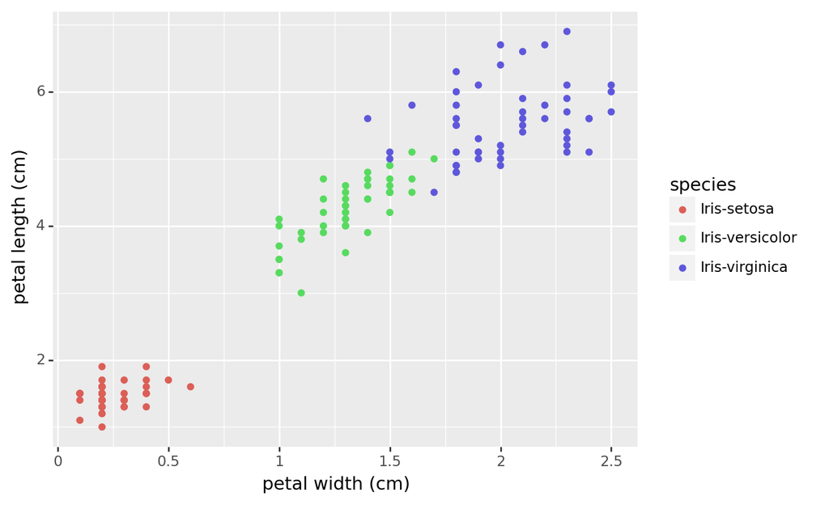

```python
df = pd.read_csv('../stan/iris-data.csv')
mydraw(
  pn.ggplot(df, pn.aes(x='petal_width', y='petal_length',
                       color='species')) +
  pn.geom_point() +
  pn.labs(x = "petal width (cm)", y = "petal length (cm)")
)
```

The three species are of very different sizes, but there is a roughly linear relation between petal width and petal length across the different species.

The width values all have exactly one decimal place of accuracy, which means they were recorded to the nearest millimeter. There are models that deal with this kind of measurement quantization, but we will not consider them now and will instead proceed as if there were no rounding of our measurements.

## 9.2 Linear regression

A simple univariate linear regression models one measurement as a linear function of another measurement. In this example, we will model an iris flower’s petal length as a linear function of its petal width. If we let $x_n$ be the petal width for flower $n$ and let $y_n$ be the petal length. A linear regression says that we expect $y_n$ to be a linear function of $x_n$, or roughly, the expected value of $y_n$ will be $\alpha + \beta \cdot x_n$ for some intercept $\alpha$ and slope $\beta$.

The linear relation in a linear regression only holds in expectation. That is, we expect the value of $y_n$ to be $\alpha + \beta \cdot x_n$, but in real observations there will be *error* due to either measurement or a failure of the linear relationship. In the Iris data plot, you can see that there are multiple irises with exactly the same measured petal width but varying petal lengths.

We can introduce a variable $\epsilon_n$ for the difference between a petal’s length and its expected length given the linear relationship,
$$y_n = \alpha + \beta \cdot x_n + \epsilon_n.$$
It is traditional to assume the error is normally distributed with a zero mean and scale $\sigma > 0$,
$$\epsilon_n \sim \textrm{normal}(0, \sigma).$$
We can rearrange terms and write this in a fashion that will mirror how it’s coded in Stan,
$$y_n \sim \textrm{normal}(\alpha + \beta \cdot x_n, \sigma).$$
In this form, it’s clear that the linear prediction is the expectation for the random variable $Y_n$ and the standard deviation is the scale,
$$\mathbb{E}[Y_n] = \alpha + \beta \cdot X_n
\qquad
\mathrm{sd}[Y_n] = \sigma.$$

Here is a simple Stan model to regress petal length on petal width; we replace $x$ with `petal_width` and $y$ with `petal_length.`

```
../stan/iris-petals.stan
```

```stan
data {
  int<lower=0> N;
  vector<lower=0>[N] petal_width;
  vector<lower=0>[N] petal_length;
}
parameters {
  real alpha;
  real beta;
  real<lower=0> sigma;
}
model {
  petal_length ~ normal(alpha + beta * petal_width, sigma);
  alpha ~ normal(0, 5);
  beta ~ normal(0, 5);
  sigma ~ lognormal(0, 1);
}
```

The data block says there are $N$ observations of petal width and length. The widths and lengths are declared to have type (column) `vector`, with a constraint `lower=0` and size (number of rows) `N.` We are declaring these types as vectors because we are going to apply vector arithmetic to them.

The model parameters are coded in the parameter block. The lower bound for `sigma` is required here as the normal distribution is only defined for positive values of `sigma.` Stan requires every parameter value that satisfies the declared constraints to be in the *support* of the density, which is the set of values for which the density is non-zero (equivalently, the log density is finite).

The model codes the regression following the math, but without the subscripts. What’s going on is that the sampling statement for `petal_length` is vectorized. The variables `petal_length` and `petal_length` are both vectors of size `N`, whereas `alpha`, `beta`, and `sigma` are all scalars. Working outward, `beta * petal_width` is a scalar times a vector, which is defined in the usual way as a vector whose `n`th entry is `beta * petal_width[n].` We then add `alpha` to that result (multiplication binds more tightly than addition and as in mathematical writing, we drop all unnecessary parentheses). This is defined by *broadcasting* so that `alpha` acts like a vector of size `N` and addition is defined in the usual way for vectors. As a result, `alpha + beta * petal_width` is a vector of size `N`, whose `n`th element is `alpha + beta * petal_width[n].` Now we have a vector for the location parameter of a normal distribution, a scalar scale (`sigma`), and a vector outcome (`petal_length`). This works by broadcasting `sigma` to use for each `n.` The end result is equivalent to the following, but much more compact and efficient.

```stan
for (n in 1:N) {
  petal_length[n] ~ normal(alpha + beta * petal_width[n], sigma);
}
```

The rest of the model is priors for the regression coefficients and error scale. The coefficients are unconstrained, but the error scale is constrained to be positive, so we use a lognormal distribution (we could have also used a half normal and we should if scales near zero are possible).

We can then compile and fit the model and display the resulting fit for `alpha` and `beta` as a scatterplot.

```python
def iris_data_frame():
    return pd.read_csv('../stan/iris-data.csv')

def iris_data():
    df = iris_data_frame()
    N = df.shape[0]
    petal_width = df['petal_width']
    petal_length = df['petal_length']
    species = 1 + pd.Series(df['species']).astype('category').cat.codes
    num_species = 3
    data = {'N': N,
            'K': num_species,
            'species': species,
            'petal_width': petal_width,
            'petal_length': petal_length,}
    return data

M = 100 if DRAFT else 1000
model = csp.CmdStanModel(stan_file = '../stan/iris-petals.stan')
sample = model.sample(data = iris_data(), seed = 123,
                      iter_warmup = M, iter_sampling = M,
                      show_progress = False, show_console = False)
sample.summary(sig_figs = 2)
```

|  | Mean | MCSE | StdDev | 5% | 50% | 95% | N_Eff | N_Eff/s | R_hat |
| --- | --- | --- | --- | --- | --- | --- | --- | --- | --- |
| lp__ | 34.00 | 0.1100 | 1.400 | 30.00 | 34.00 | 35.00 | 160.0 | 9900.0 | 1.0 |
| alpha | 1.10 | 0.0066 | 0.079 | 0.97 | 1.10 | 1.20 | 140.0 | 8900.0 | 1.0 |
| beta | 2.20 | 0.0046 | 0.054 | 2.10 | 2.20 | 2.30 | 140.0 | 8800.0 | 1.0 |
| sigma | 0.48 | 0.0022 | 0.029 | 0.43 | 0.48 | 0.53 | 170.0 | 11000.0 | 1.0 |

This summary doesn’t give us a good feeling for the uncertainty in the linear relationship. To do that, we will plot multiple draws from the posterior along with the data.

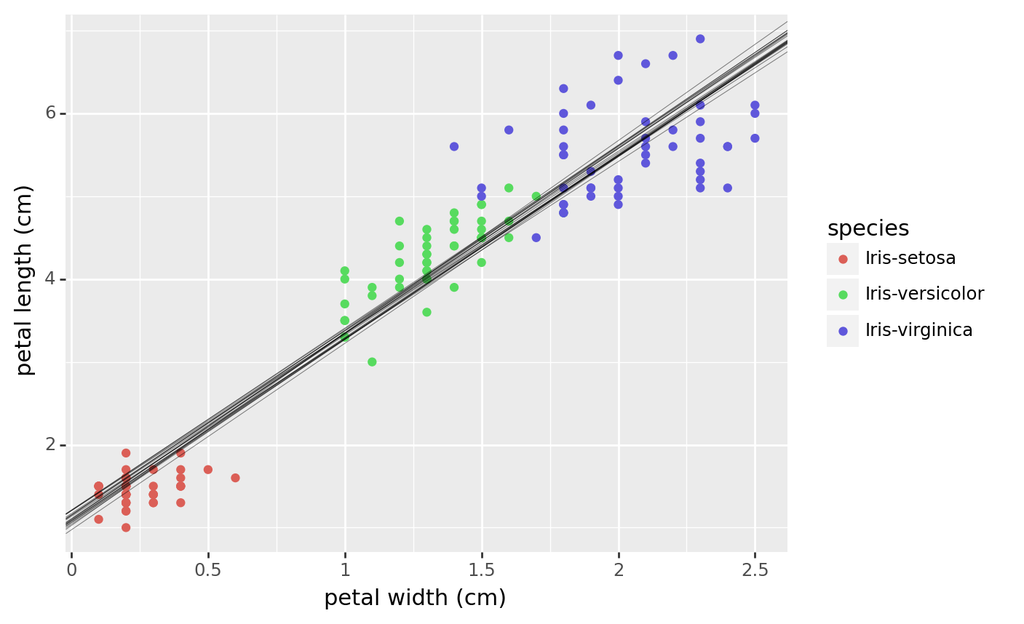

```python
alpha_draws = sample.stan_variable('alpha')
beta_draws = sample.stan_variable('beta')
plot =  pn.ggplot(df, pn.aes(x='petal_width', y='petal_length',
                             color='species'))
plot = plot +  pn.geom_point()
plot = plot +  pn.labs(x = "petal width (cm)", y = "petal length (cm)")
for a, b in zip(alpha_draws[0:20], beta_draws[0:20]):
    plot = plot + pn.geom_abline(intercept = a, slope = b,
                                 alpha = 0.5, size = 0.2)
mydraw(
  plot
)
```

We didn’t include the error scale, but it’s roughly 0.5. That means it won’t be uncommon to get errors greater than 1 or less than -1. For *iris setosa*, this could easily result in predictions with negative lengths!

## 9.3 Built-in generalized linear model functions

Stan supplies built-ins for the most common generalized linear model (GLM) functions. These allow linear and non-linear regressions to be coded easily and efficiently. For example, our linear regression could be coded with the `normal_id_glm` function and a logistic regression coded with the `bernoulli_logit_glm`. The linear regression for the Iris data could be written as follows

```stan
  petal_length ~ normal_id_glm(petal_width, alpha, beta, sigma);
```

if the data and parameter type declarations are generalized to

```stan
  matrix<lower=0>[N, 1] petal_width;
  vector[N] petal_length;
  real alpha;
  vector[1] beta;
  real<lower=0> sigma;
```

The generalization of a vector of predictors to a matrix allows multivariate regressions with multiple predictors per item (e.g., using population density, speed limit, traffic density, and time of day to predict pedestrian traffic accidents).

## 9.4 Robust regression

Although we won’t consider this model in detail, Stan’s plug-and-play design makes it very simple to convert our linear regression into a *robust regression* by swapping out the normal error model for a Student-t error model,

```stan
  petal_length ~ student_t(dof, alpha + beta * petal_width, sigma);
```

We have just used `dof` for the degrees of freedom variable, but setting it at a value like `4` provides wider tails and setting it at `1` produces the very wide-tailed Cauchy distribution, which does not even have a finite mean or variance.

## 9.5 Posterior predictive inference

Now let’s say we have a new observation where we know the petal width and want to predict its length. Mathematically, to make a prediction for a new item, we use *posterior predictive inference*.

First, let’s consider evaluating the log density of a new petal’s length ($\tilde{y}$) given its observed width ($\tilde{x}$), having observed our original data $x$ and $y$. In Bayesian inference, we evaluate the *posterior predictive distribution*, where we let $\Theta$ be our random parameters with realization $\theta$,
$$\begin{align}
p(\tilde{y} \mid \tilde{x}, x, y)
&= \mathbb{E}[p(\tilde{y} \mid \tilde{x}, \theta) \mid x, y]
\\[6pt]
&= \int_{\Theta} p(\tilde{y} \mid \tilde{x}, \theta) \cdot p(\theta \mid x, y) \, \textrm{d}\theta
\\[6pt]
&\approx \frac{1}{M} \sum_{m=1}^M \, p(\tilde{y} \mid \tilde{x}, \theta^{(m)}),
\end{align}$$
where $\theta^{(1)}, \ldots, \theta^{(m)} \sim p(\theta \mid x, y)$ are draws from the posterior. The parameters are marginalized out. It’s perhaps easiest to understand by considering the Monte Carlo approximation, which just averages the sampling log density over draws of parameters from the posterior.

### Sampling uncertainty and estimation uncertainty

It can help to break the integral down into the two components of uncertainty, sampling uncertainty due to our sampling distribution and posterior uncertainty in the values of our parameters,
$$\int_{\Theta}
\underbrace{p(\tilde{y} \mid \tilde{x}, \theta)}_{\textrm{sampling uncertainty}}
\cdot
\underbrace{p(\theta \mid x, y)}_{\textrm{estimation uncertainty}}
\, \textrm{d}\theta$$
In our case, $\theta = \begin{bmatrix}\alpha & \beta & \sigma\end{bmatrix}$ and the sampling distribution is
$$p(\tilde{y} \mid \tilde{x}, \alpha, \beta, \sigma)
=
\textrm{normal}(\tilde{y} \mid \alpha + \beta \cdot \tilde{x}, \sigma).$$
Even if we know the parameter values $\alpha$, $\beta$, and $\sigma$ exactly, we can only predict $\tilde{y}$ to within $\epsilon$, where $\epsilon \sim \textrm{normal}(0, \sigma)$. If we plug in a point estimate $\widehat{\alpha}, \widehat{\beta}, \widehat{\sigma}$ for our parameters, we might get approximate inference that takes into account sampling uncertainty, but not estimation uncertainty, e.g.,
$$p(\tilde{y} \mid \tilde{x}, x, y)
\approx
p(\tilde{y} \mid \tilde{x}, \widehat{\alpha}, \widehat{\beta}, \widehat{\sigma}).$$

So far, this only gives us a way to evaluate the log density of a resulting outcome $\tilde{y}$ given a predictor $\tilde{x}$. If we want to simulate possible $\tilde{y}$, we have to make sure to add sampling uncertainty and draw
$$\tilde{y}^{(m)} \sim \textrm{normal}\!\left(\alpha^{(m)} + \beta^{(m)} \cdot \tilde{x} \mid \sigma^{(m)}\right),$$

where $\alpha^{(m)}, \beta^{(m)}, \sigma^{(m)} \sim p(\alpha, \beta, \sigma \mid x, y)$ are posterior draws. In general, if we then want to estimate $\tilde{y}$, we can take posterior means of these values. In the case here, our sampling distribution is symmetric, so that the expectation of the random draws and the expectation of their mean is identical. If our only goal is to estimate an expectation, it is better to average expectations than to average random draws with those expectations. This is formalized in the [*Rao-Blackwell theorem*](https://en.wikipedia.org/wiki/Rao%E2%80%93Blackwell_theorem). Converting an estimator that uses a sample to one that uses expectations of that sample is called “Rao-Blackwellization.”

### Standalone generated quantities

Let’s put all this together into a Stan program. First, let’s make posterior predictions for some new $\tilde{y}$. We can do this using Stan’s *standalone generated quantities* feature that lets us run the generated quantities block of a new model given draws from another model. We could’ve also just included the generated quantities block in the original program.

[output not shown]

```stan
data {
  int<lower=0> N_tilde;
  vector<lower=0>[N_tilde] petal_width_tilde;
}
parameters {
  real alpha;
  real beta;
  real<lower=0> sigma;
}
generated quantities {
  vector<lower=0>[N_tilde] E_petal_length_tilde
    = alpha + beta * petal_width_tilde;
  vector<lower=0>[N_tilde] petal_length_tilde
    = to_vector(normal_rng(E_petal_length_tilde, sigma));
}
```

This program declares two new data variables, `N_tilde` for the number of predicted items, and `petal_width_tilde`, a vector of petal widths of size `N_tilde.`

It is important that the program used for standalone generated quantities use *exactly the same parameters* as the original program. After our original fit, we read that sample back in for the parameters, then run generated quantities (and the transformed parameter block if there is one).

The generated quantities block first calculates the expected petal length given the petal width and assigns it to the variable `E_petal_length_tilde.` This code is vectorized so that it calculates all of the input petal widths at once. The second variable is then set by sampling according to the sampling distribution using the `normal_rng` function. This function is also vectorized, but it returns an array, so we convert it to a vector just to keep all the types the same.

```python
data = {'N_tilde': 3,
        'petal_width_tilde': [0.4, 1.75, 3.8]}
model = csp.CmdStanModel(
     stan_file = '../stan/iris-posterior-predictive-sim.stan')
pps_sample = model.generate_quantities(data = data, seed = 123,
                                       previous_fit = sample,
                                       show_console = False)
print('Estimated petal lengths given petal widths')
for i in range(3):
  length_draws = \
      pps_sample.stan_variable('petal_length_tilde')[0:100, i]
  E_length_draws = \
      pps_sample.stan_variable('E_petal_length_tilde')[0:100, i]
  print(f"petal_width_tilde[{i}] = {data['petal_width_tilde'][i]}")
  print(f"  mean(E_petal_length_tilde[{i}]) = {np.mean(E_length_draws):.2f}")
  print(f"  sd(E_petal_length_tilde[{i}]) = {np.std(E_length_draws):.2f}")
  print(f"  mean(petal_length_tilde[{i}]) = {np.mean(length_draws):.2f}")
  print(f"  sd(petal_length[{i}]) = {np.std(length_draws):.2f}\n")
```

```
Estimated petal lengths given petal widths
petal_width_tilde[0] = 0.4
  mean(E_petal_length_tilde[0]) = 1.98
  sd(E_petal_length_tilde[0]) = 0.06
  mean(petal_length_tilde[0]) = 1.88
  sd(petal_length[0]) = 0.44

petal_width_tilde[1] = 1.75
  mean(E_petal_length_tilde[1]) = 4.98
  sd(E_petal_length_tilde[1]) = 0.05
  mean(petal_length_tilde[1]) = 4.96
  sd(petal_length[1]) = 0.52

petal_width_tilde[2] = 3.8
  mean(E_petal_length_tilde[2]) = 9.55
  sd(E_petal_length_tilde[2]) = 0.14
  mean(petal_length_tilde[2]) = 9.52
  sd(petal_length[2]) = 0.48
```

For each of our input petal widths $[0.4 \quad 1.75 \quad 3.8]$, we see the posterior mean prediction for petal width and its standard deviation calculated two ways. First, we take the posterior draws for the expected petal length, `E_petal_length_tilde`, which is just the linear prediction of petal value. The uncertainty comes only from estimation uncertainty in $\alpha$ and $\beta$. Second, we take the posterior draws for petal length, which include an additional normal error term with scale $\sigma$. The means are roughly the same either way, but the standard deviation is much higher in the case of sampling. The second variable, `petal_length_tilde`, includes both sources of posterior uncertainty, estimation uncertainty and uncertainty from the sampling distribution.

## 9.6 Lognormal and transformed data

In this section, we will convert our iris model to the log scale using the transformed data block to convert the petal width to a log scale and use a lognormal regression on the width to predict the length.

The *lognormal distribution* is a simple transform of a normal distribution with support over positive values. If
$$U \sim \textrm{lognormal}(\mu, \sigma),$$
then
$$log U \sim \textrm{normal}(\mu, \sigma).$$
This will allow us to transform our Stan program. We first translate the petal width to the log scale in the transformed data block, then model length as a lognormal regression on log width in the model block.

```
../stan/iris-petals-log.stan
```

```stan
data {
  int<lower=0> N;
  vector<lower=0>[N] petal_width;
  vector<lower=0>[N] petal_length;
}
transformed data {
  vector[N] log_petal_width = log(petal_width);
}
parameters {
  real alpha;
  real beta;
  real<lower=0> sigma;
}
model {
  petal_length ~ lognormal(alpha + beta * log_petal_width, sigma);
  alpha ~ normal(0, 3);
  beta ~ normal(0, 3);
  sigma ~ lognormal(0, 0.6);
}
```

We have introduced a new block for transformed data, in which we have defined a vector of log petal widths to use as a predictor. The petal lengths are already positive and we do not modify those. The effect is that we are regressing log petal length on log petal width and the sampling statement could have been replaced with

```stan
  log(petal_length) ~ normal(alpha + beta * log_petal_width, sigma);
```

The result would be the same up to a constant normalizing term involving petal length (which is constant) in the lognormal density.

Let’s run the model and summarize the results.

```python
M = 100 if DRAFT else 1000
log_model = csp.CmdStanModel(stan_file =
                               '../stan/iris-petals-log.stan')
log_sample = log_model.sample(data = iris_data(), seed = 123,
                              iter_warmup = M, iter_sampling = M,
                              show_progress = False,
                  show_console = False)
log_sample.summary(sig_figs = 2)
```

|  | Mean | MCSE | StdDev | 5% | 50% | 95% | N_Eff | N_Eff/s | R_hat |
| --- | --- | --- | --- | --- | --- | --- | --- | --- | --- |
| lp__ | 56.00 | 0.09600 | 1.2000 | 53.00 | 56.00 | 57.00 | 160.0 | 9800.0 | 1.0 |
| alpha | 1.30 | 0.00063 | 0.0130 | 1.30 | 1.30 | 1.30 | 440.0 | 28000.0 | 1.0 |
| beta | 0.57 | 0.00049 | 0.0130 | 0.55 | 0.57 | 0.59 | 760.0 | 47000.0 | 1.0 |
| sigma | 0.16 | 0.00110 | 0.0096 | 0.15 | 0.16 | 0.18 | 79.0 | 5000.0 | 1.0 |

The estimated values ae $\widehat{\alpha} = 1.3$ and $\widehat{\beta} = 0.57$ and $\sigma = 0.16$. One advantage of the log scale is that the regression makes more sense because $\exp(\alpha + \beta \cdot \log w) = \exp(\alpha) \cdot w^{\beta}$. By taking exponents, the intercept $\alpha$ becomes a multiplicative factor $\exp(\alpha)$ and the slope $\beta$ becomes an exponent. The error also moves to the multiplicative scale, which makes it relative. Multiplicative error makes sense here as we wouldn’t expect the same error scale for petals of width 0.5cm as for petals of width 5cm. The final relationship derived through this model is as follows.
$$\begin{align}
\textrm{length}
&= \exp(\alpha + \beta * \log(\textrm{width}) \ \pm \ 2 \cdot \sigma)
\\[6pt]
&= 3.67 \cdot \textrm{width}^{0.56} \cdot 1.38^{\pm 1}.
\end{align}$$
The plus or minus 1 on the exponent turns into either multiplication or division by 1.38.

The posterior intervals are tighter for the lognormal model, which generally indicates a better fit to data. Let’s see what the data and twenty posterior draws of the regression look like on the log scale.

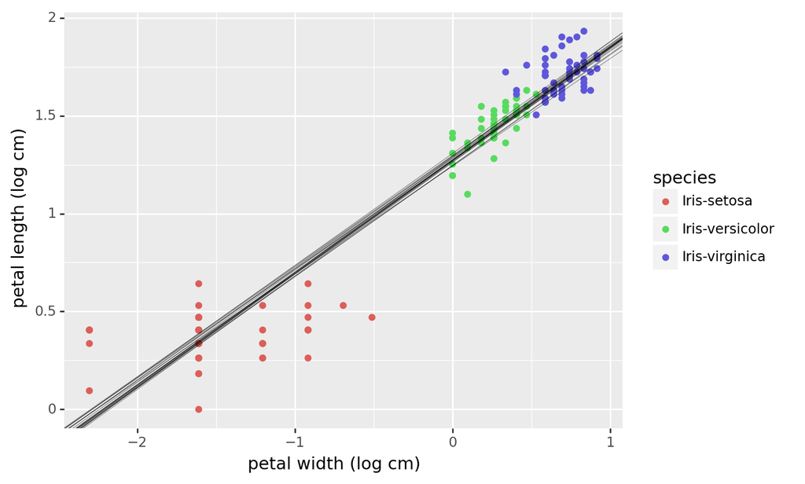

```python
df = iris_data_frame()
df['log_petal_length'] = np.log(df['petal_length'])
df['log_petal_width'] = np.log(df['petal_width'])
alpha_draws = log_sample.stan_variable('alpha')
beta_draws = log_sample.stan_variable('beta')
plot =  pn.ggplot(df, pn.aes(x='log_petal_width',
                             y='log_petal_length',
                 color='species'))
plot = plot +  pn.geom_point()
plot = plot +  pn.labs(x = "petal width (log cm)",
                       y = "petal length (log cm)")
for a, b in zip(alpha_draws[0:20], beta_draws[0:20]):
    plot = plot + pn.geom_abline(intercept = a, slope = b,
                                 alpha = 0.5, size = 0.2)
mydraw(plot)
```

Now the *iris versicolor* and *iris virginica* look good, but the smaller *iris setosa* is still poorly characterized. We’ll fix this problem in the next section.

## 9.7 Multi-indexing: varying slopes and varying intercepts

We can see from the previous section that a single regression line doesn’t fit all three species of iris well. While the lognormal model is better than the linear model, it still fails to capture the characteristics of the smaller *iris setosa*.

On the log scale, it does look like it will be possible to capture *iris setosa*’s scale, as long we can build separate regressions for each species. The varying slopes and varying intercepts are sometimes called *random effects*, in contrast to the previous models’ *fixed effects*, which do not vary by data grouping.

Mathematically, we now have three intercepts three slopes, one pair for each species of iris. We will represent these as 3-vectors, $\alpha, \beta \in \mathbb{R}^3$. Given our $N$ data items, we will introduce an indexing data item $\textrm{species} \in \{ 1, 2, 3 \}^N$, where $\textrm{species}_n$ is the species of the $n$-th data item. Sticking to the log scale, our regression now looks like this,
$$\textrm{length}_n
\sim \textrm{lognormal}(\alpha_{\textrm{species}_n}
+ \beta_{\textrm{species}_n} \cdot \log \textrm{width}_n,
\sigma).$$
The value $\alpha_{\textrm{species}_n}$ is the intercept for $\textrm{species}_n \in \{1, 2, 3\}$. We have kept the same error term $\sigma$, though we could have also split that out on a per-species basis like the slope and intercept.

The Stan code follows the statistical notation.

```
../stan/iris-petals-varying.stan
```

```stan
data {
  int<lower=0> N;
  vector<lower=0>[N] petal_width;
  vector<lower=0>[N] petal_length;
  int<lower=0> K;
  array[N] int<lower=1, upper=K> species;
}
transformed data {
  vector[N] log_petal_width = log(petal_width);
}
parameters {
  vector[K] alpha;
  vector[K] beta;
  real<lower=0> sigma;
}
model {
  petal_length ~ lognormal(alpha[species] + beta[species] .* log_petal_width,
                           sigma);
  alpha ~ normal(0, 3);
  beta ~ normal(0, 3);
  sigma ~ lognormal(0, 0.6);
}
```

Here, we take $K$ to be the number of species and the species indicator thus takes on values between $1$ and $K$ (inclusive). Where before we had `alpha` and `beta` for the intercept and slope, we now have `alpha[species]` and `beta[species].` These will pick our vectors of size $N$ (number of data items), as explained below. Further, the product of the slope and width is now an elementwise product (`.*`), which we also consider below. The sampling statement above is equivalent to

```stan
for (n in 1:N) {
  petal_length[n]
    ~ lognormal(alpha[species[n]] + beta[species[n]] * log_petal_width[n],
                sigma);
}
```

### Elementwise products in Stan

The elementwise product (`.*`) uses MATLAB syntax and is defined so that

```stan
(a .* b)[n] == a[n] * b[n]  // true
```

Elementwise division (`./`) works the same way and we don’t need elementwise addition or subtraction because those operations are already defined as regular vector addition and subtraction.

### Multi-indexing in Stan

This model uses a technique we call multi-indexing and it works the similarly to the way indexing works in NumPy. Suppose we have a vector of size `J` and an array of indexes of size `N.`

```stan
array[N] int<lower=1, upper=J> idxs;
vector[J] foo;
```

We can use the multiple indexes in `idxs` to index `foo` as `foo[idxs].` The result is a size `N` vector (the type is taken from `foo` and the size from `idxs`), with values given by indexing into `idxs`. Indexing is defined as follows.

```stan
cols(foo[idxs]) == N          // true
foo[idxs][n] == foo[idxs[n]]  // true
```

This tells us the number of columns of `foo[idxs]` is `N` and that indexing is done by first indexing into `idxs` and then using the result.

This works the same way for range indexing, such as `foo[1:3]`, and for indexing with array literals like `{7, 9, 3}`, e.g.,

```stan
foo[3:5] == {foo[3], foo[4], foo[5]}         // true
foo[{7, 9, 3}] == {foo[7], foo[9], foo[3]}   // true
```

### Fitting our varying effects model

First, we add a `species` column to our data frame to represent the species of the iris as an integer 1, 2, or 3. Then we will just read in the data and fit and summarize the results.

```python
M = 100 if DRAFT else 1000
vary_model = csp.CmdStanModel(
                  stan_file = '../stan/iris-petals-varying.stan')
vary_sample = vary_model.sample(data = iris_data(), seed = 123,
                                iter_warmup = M, iter_sampling = M,
                                show_progress = False,
                show_console = False)
vary_sample.summary(sig_figs = 2)
```

|  | Mean | MCSE | StdDev | 5% | 50% | 95% | N_Eff | N_Eff/s | R_hat |
| --- | --- | --- | --- | --- | --- | --- | --- | --- | --- |
| lp__ | 130.000 | 0.1600 | 1.800 | 130.000 | 130.000 | 130.00 | 130.0 | 1700.0 | 1.0 |
| alpha[1] | 0.490 | 0.0027 | 0.050 | 0.400 | 0.490 | 0.57 | 339.0 | 4297.0 | 1.0 |
| alpha[2] | 1.300 | 0.0016 | 0.028 | 1.200 | 1.300 | 1.30 | 287.0 | 3632.0 | 1.0 |
| alpha[3] | 1.500 | 0.0063 | 0.073 | 1.400 | 1.500 | 1.70 | 136.0 | 1718.0 | 1.0 |
| beta[1] | 0.074 | 0.0018 | 0.032 | 0.020 | 0.072 | 0.13 | 314.0 | 3972.0 | 1.0 |
| beta[2] | 0.590 | 0.0051 | 0.088 | 0.450 | 0.590 | 0.74 | 303.0 | 3834.0 | 1.0 |
| beta[3] | 0.230 | 0.0090 | 0.110 | 0.035 | 0.240 | 0.40 | 138.0 | 1748.0 | 1.0 |
| sigma | 0.100 | 0.0000 | 0.000 | 0.100 | 0.100 | 0.10 | 310.1 | 3925.0 | 1.0 |

There are a few things worth noting in this summary. First, recall that the parameter estimates in the fixed effects model were $\widehat{\alpha} = 1.3$, $\widehat{\beta} = 0.57$, and $\widehat{\sigma} = 0.16$. In the varying effects model, we see that the estimates for $\alpha_k$ and $\beta_k$ vary considerably by $k$. For example, as we see in the data, there is very little effect of width on length for *iris setosa*, with $\widehat{\beta}_1 = 0.075$, wheres there is a large effect for *iris versicolor* of $\widehat{\beta}_2 = 0.6$. Furthermore, our value for $\sigma$ is lower, which indicates lower residual error in our predictors. We will leave evaluating varying error scales to the reader.

We now have three different regression lines, which we plot on the log scale with color matching the data..

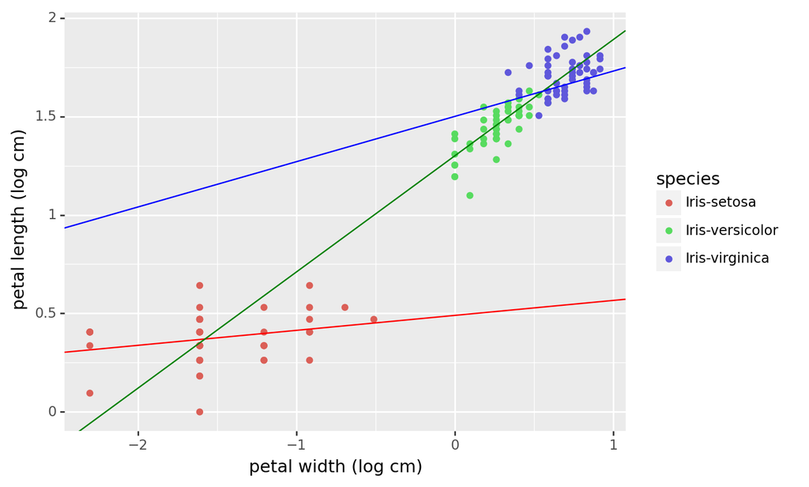

```python
df = iris_data_frame()
df['log_petal_length'] = np.log(df['petal_length'])
df['log_petal_width'] = np.log(df['petal_width'])
plot =  pn.ggplot(df, pn.aes(x='log_petal_width',
                             y='log_petal_length',
                 color='species'))
plot = plot +  pn.geom_point()
plot = plot +  pn.labs(x = "petal width (log cm)",
                       y = "petal length (log cm)")
plot = plot + pn.geom_abline(intercept = .49, slope = 0.076, color='red')
plot = plot + pn.geom_abline(intercept = 1.30, slope = 0.59, color='green')
plot = plot + pn.geom_abline(intercept = 1.50, slope = 0.23, color='blue')
mydraw(
  plot
)
```

We now have a good fit for each of the groups and, as we might expect, a lower error scale $\sigma$ than for the model with a single regression.

# 10 Containers: arrays, vectors, and matrices

Stan is strongly typed, and each of the types has a distinct purpose. Constraints act as error checks in the data, transformed data, transformed parameter, and generated quantities blocks. In the parameter block, they are used to transform from unconstrained to constrained values (with an implicit change of variables adjustment). Stan Development Team (2023b) provides complete details or the full set of transforms, inverse transforms, and their log absolute Jacobian determinants.

## 10.1 Integer and real primitives

The two primitive types are `int` and `real.` In the compiled C++ code, these are 32-bit signed integers and 64-bit floating point values, respectively.

The third scalar type is `complex`, where a complex value consists of a real component and an imaginary component, both of which are represented as 64-bit floating point values.

### Constrained primitive types

Integer and real types may be constrained with lower bounds, upper bounds, or both. For example, `real<lower=0>` is the type for a concentration, `real<lower=0, upper=1>` is the type for a probability, `real<lower=-1, lower=1>` is the type for a correlation, `int<lower=0>` is the type for a count, and `int<lower=1, upper=5>` is the type for an ordinal response to a survey.

There is a second kind of modifier, which is not technically a constraint, but is a transform. If we declare

```stan
vector<offset=mu, multiplier=sigma>[K] alpha;
```

then the unconstrained representation is multiplied by `sigma` and then offset by `mu` to get the constrained value `alpha`. This is primarily used for non-centered parameterizations of hierarchical models, which are beyond this tutorial.

## 10.2 Arrays

For any type `T`, we can write `array[N] T` for the type of an array of size `N` containing elements of type `T.` We can also write `array[M, N] T` for a 2D array and so on for higher dimensionality. For example, `array[3, 2] int` is a two-dimensional array of integers of shape 3 by 2.

## 10.3 Matrices

The type `matrix[M, N]` is for an $M \times N$ matrix. The type `complex_matrix[M, N]` is for an $M \times N$ matrix with complex values.

### Constrained matrix types

There are four special matrix types. The type `cov_matrix` is for positive definite matrices, whereas `cholesky_factor_cov` is for Cholesky factors of positive definite matrices. The type `corr_matrix` is for positive definite matrices with unit diagonals and `cholesky_factor_corr` is for Cholesky factors of correlation matrices. The Cholesky factors are lower triangular and should be preferred to the full matrices where possible.

## 10.4 Vectors and row vectors

The type `vector[M]` is for column vectors with `M` rows, whereas `row_vector[N]` is for row vectors with `N` columns. A column vector is like an $M \times 1$ matrix and a row vector is like a $1 \times N$ vector. There are also `complex_vector` and `complex_row_vector` types which work the same way.

The reason we do not just represent vectors as matrices is that we are able to reduce types in arithmetic. For example, the product of a row vector and a product vector is a scalar rather than a $1 \times 1$ matrix. Similarly, the product of a matrix and a vector is a vector.

### Constrained vector types

There is a vector type `ordered[M]` for vectors in ascending order, and a similar type `pos_ordered[M]` for vectors of non-negative values in ascending order.

The vector type `unit_vector[M]` is for vectors of unit Euclidean length (i.e., the sum of squared values is one). There is also a `simplex[M]` type for simplex (non-negative values that sum to one).

### Assignment and function calls

Calling a function works like assigning the variables in the argument list to the variables in the function declaration. In general, Stan is what programming language researchers call *covariant*, meaning that if a type `T` is assignable to a type `U`, then a type `array[N] T` is assignable to `array[N] U`. Similarly, integer-valued primitives and containers may be assigned to their real or complex counterparts, and real-valued primitives and containers may be assigned to their complex counterparts (but not the other way around). Variables of a constrained type may be assigned to variables of an unconstrained type.

# 11 Stan Example: Discrete parameters and mixture models

Although Stan only allows parameters which are real or complex valued, it is able to work with models involving discrete parameters by marginalizing them out in the likelihood and working in expectation during inference.

There are two reasons Stan doesn’t allow discrete parameters. First, because Stan isn’t limited to directed graphical models, it’s technically impossible to pull out efficient conditional distributions for the discrete parameters in general (though it can be done in some limited cases). Second, discrete sampling tends not to perform very well because the parameters tend to get locked and not mix well.

## 11.1 Normal mixture model

We’ll consider a simple two-component normal mixture model parameterized with a discrete responsibility parameter. This model assumes that each item $y_n$ is drawn from one of two possible normal distributions, $\textrm{normal}(\mu_1, \sigma_1)$ or $\textrm{normal}(\mu_2, \sigma_2)$, with a probability $\lambda \in [0, 1]$ of being drawn from the first distribution. Let’s assume we have $N$ observations $y_n \in \mathbb{R}$. We will use $z_n \in \{ 0, 1 \}$ as the discrete parameter representing the distribution from which $y_n$ arose. This gives us the following model
$$\begin{align}
z_n &\sim \textrm{bernoulli}(\lambda)
\\[6pt]
y_n &\sim \textrm{normal}(\mu_{z_n}, \sigma_{z_n})
\end{align}$$
In frequentist settings, the parameters $z_n$ are sometimes called *missing data* to finesse a philosophical aversion to probability distributions over parameters.

## 11.2 Marginalization to the rescue

The immediate problem is that we cannot code this model in Stan by just following the math because we do not have discrete parameters. But what we can do is *marginalize* out the discrete parameters. We know from the *law of total probability* that if $B$ is a discrete random variable, then we can derive the marginal probability $p(a)$ from the joint probability function $p(a, b)$ by
$$p(a) = \sum_{b \in B} p(a, b).$$

We can express our mixture model’s sampling distribution over both $y$ and $z$,
$$p(y, z \mid \lambda, \mu, \sigma)
= \prod_{n = 1}^N p(y_n, z_n \mid \lambda, \mu, \sigma).$$
This is called the *complete data likelihood* in frequentist settings.

Then we can evaluate the likelihood elementwise,
$$p(y_n, z_n \mid \lambda, \mu, \sigma)
= \textrm{bernoulli}(z_n \mid \lambda)
\cdot \textrm{normal}(y_n \mid \mu_{z_n}, \sigma_{z_n}).$$
Now we can marginalize out the $z_n$ by considering values 0 and 1,
$$\begin{align}
p(y_n \mid \lambda, \mu, \sigma)
&= p(y_n, z_n = 1 \mid \lambda, \mu, \sigma)
+ p(y_n, z_n = 0 \mid \lambda, \mu, \sigma)
\\[6pt]
&= \textrm{bernoulli}(1 \mid \lambda) \cdot \textrm{normal}(y_n \mid \mu_1, \sigma_1)
\\[2pt]
& \qquad + \ \textrm{bernoulli}(0 \mid \lambda) \cdot \textrm{normal}(y_n \mid \mu_2, \sigma_2).
\end{align}$$
We can further substitute in the value for the Bernoulli densities, which are
$$\begin{align}
\textrm{bernoulli}(1 \mid \lambda) &= \lambda, \ \textrm{and}
\\[4pt]
\textrm{bernoulli}(0 \mid \lambda) &= 1 - \lambda,
\end{align}$$
to produce the standard form of the mixture model sampling distribution,
$$p(y_n \mid \lambda, \mu, \sigma)
= \lambda \cdot \textrm{normal}(y_n \mid \mu_1, \sigma_1)
+ (1 - \lambda) \cdot \textrm{normal}(y_n \mid \mu_2, \sigma_2).$$

## 11.3 Simulated data: adult height of men and women

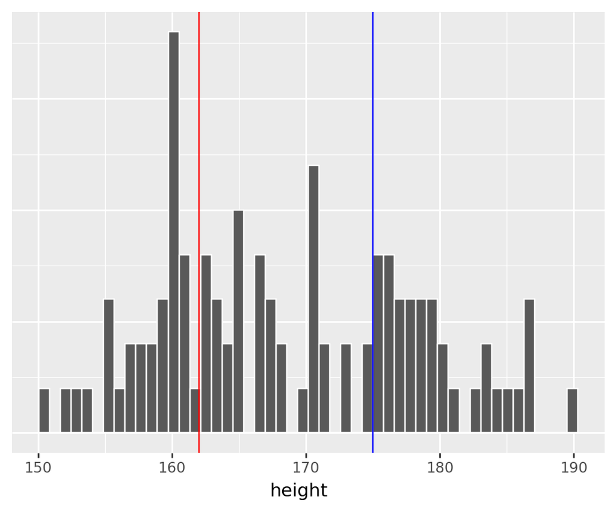

```python
M = 100 if DRAFT else 5_000
female_mean_height_cm = 162
male_mean_height_cm = 175
female_sd_height_cm = 6.3
male_sd_height_cm = 7.5
prob_female = 0.51
mu = np.array([female_mean_height_cm, male_mean_height_cm])
sigma = np.array([female_sd_height_cm, male_sd_height_cm])
sex = np.array(np.random.binomial(n = 1, p = prob_female, size=M))
heights = np.random.normal(loc = mu[sex], scale = sigma[sex], size=M)

mydraw(
  pn.ggplot(pd.DataFrame({'height': heights}),
                 pn.aes(x = 'height')) +
  pn.geom_histogram(bins=50, color='white') +
  pn.labs(x = 'height') +
  pn.geom_vline(xintercept=162, color='red') +
  pn.geom_vline(xintercept=175, color='blue') +
  pn.theme(axis_text_y = pn.element_blank(),
           axis_title_y = pn.element_blank(),
           axis_ticks_major_y = pn.element_blank())

)
```

## 11.4 The log scale and log sum of exponents operation

We have successfully marginalized out the $z$ and derived $p(y \mid \lambda, \mu, \sigma)$, but this leaves us with a residual problem—Stan works on the log scale and we have done our derivation on the linear scale. That is, we start with
$$\begin{align}
\log p(y_n \mid \lambda, \mu, \sigma)
=
\log\! \big( \, \strut & \textrm{bernoulli}(0 \mid \lambda) \cdot \textrm{normal}(y_n \mid \mu_0, \sigma_0)
\\[2pt]
& + \textrm{bernoulli}(1 \mid \lambda) \cdot \textrm{normal}(y_n \mid
\mu_1, \sigma_1)\, \big).
\end{align}$$
To reduce this further, we are going to use the *log-sum-exp* operation, which is defined by
$$\textrm{log-sum-exp}(a, b)
= \log \left( \strut \exp(a) + \exp(b)\right).$$

The reason we use log-sum-exp is that it can be made arithmetically stable in such a way as to prevent numerical overflow by pulling out the maximum value,
$$\textrm{log-sum-exp}(a, b)
= \textrm{max}(a, b)
+ \textrm{log-sum-exp}(a - \textrm{max}(a, b), \
b - \textrm{max}(a, b))
\\[4pt]$$
This form eliminates numerical overflow because exponentiation is only applied to the terms $\left( a - \textrm{max}(a, b)\right)$ and $\left(b - \textrm{max}(a, b)\right)$, both of which must be less than or equal to zero by construction. Underflow is mitigated by pulling the leading term $\textrm{max}(a, b)$ out of the sum.

Using log-sum-exp, we can now rewrite our marginalized individual item likelihood as
$$\begin{align}
\log p(y_n \mid \lambda, \mu, \sigma)
= \textrm{log-sum-exp}\big( &\log \textrm{bernoulli}(0 \mid \lambda)
+ \log \textrm{normal}(y_n \mid \mu_0, \sigma_0),
\\[2pt]
&\log \textrm{bernoulli}(1 \mid \lambda)
+ \log \textrm{normal}(y_n \mid \mu_1, \sigma_1)
\big).
\end{align}$$

## 11.5 Stan program for mixtures

As in our earlier examples, the Stan code for mixtures just follows the mathematical definitions.

```
heights.stan
```

```stan
data {
  int<lower=0> M;
  vector<lower=0>[M] heights;
}
parameters {
  real<lower=0, upper=1> lambda;
  ordered[2] mu;
  vector<lower=0>[2] sigma;
}
model {
  mu ~ normal(170, 10);
  sigma ~ lognormal(log(7), 1);
  for (m in 1:M) {
    real lp1 = bernoulli_lpmf(0 | lambda)
        + normal_lpdf(heights[m] | mu[1], sigma[1]);
    real lp2 = bernoulli_lpmf(1 | lambda)
        + normal_lpdf(heights[m] | mu[2], sigma[2]);
    target += log_sum_exp(lp1, lp2);
  }
}
```

This program uses local variables `lp1` and `lp2.` These have scope just within the for-loop and take on different values with each loop iteration. In general, local variables can be assigned and reassigned in Stan. They are declared with sizes, but cannot have constraints.

Unlike in the original model, we have to index `mu` and `sigma` from 1 because Stan arrays are indexed from 1. The biggest departure from the mathematical model as written is that we have declared `mu` to be of type `ordered`, which is the type of a vector of increasing values. The reason we do this is that the indexes are not well identified in the sense that swapping indexes preserves the same likelihood. This way, the smaller component will be the first component and the model will be identified without changing the likelihood. Betancourt (2017b) provides more details on how this works and shows that ordering does not change the underlying model.

We have included weakly informative priors for `mu` and `sigma` based on our prior knowledge of heights. The likelihood then just follows the mathematical definition. We had to resort to a loop because Stan isn’t currently able to vectorize mixtures.

## 11.6 Fitting the simulated data

Now we can fit our simulated data.

```python
model = csp.CmdStanModel(stan_file = '../stan/heights.stan')
data = {'M': M, 'heights': heights}
J = 100 if DRAFT else 1000
sample = model.sample(data = data, seed = 123,
                      iter_warmup = J, iter_sampling = J,
                      show_progress = False, show_console = False)
sample.summary(sig_figs = 2)
```

|  | Mean | MCSE | StdDev | 5% | 50% | 95% | N_Eff | N_Eff/s | R_hat |
| --- | --- | --- | --- | --- | --- | --- | --- | --- | --- |
| lp__ | -370.00 | 1.200 | 5.70 | -380.00 | -360.00 | -360.00 | 22.0 | 24.0 | 1.2 |
| lambda | 0.57 | 0.035 | 0.19 | 0.34 | 0.53 | 0.99 | 31.0 | 35.0 | 1.1 |
| mu[1] | 159.00 | 2.100 | 9.10 | 144.00 | 161.00 | 164.00 | 19.0 | 21.0 | 1.2 |
| mu[2] | 175.00 | 0.570 | 3.30 | 168.00 | 176.00 | 179.00 | 34.0 | 38.0 | 1.1 |
| sigma[1] | 6.10 | 1.200 | 9.60 | 2.90 | 4.70 | 9.00 | 63.0 | 69.0 | 1.0 |
| sigma[2] | 7.20 | 0.260 | 1.70 | 4.50 | 7.00 | 10.00 | 42.0 | 47.0 | 1.1 |

## 11.7 Built-in Stan function for mixtures

For simple mixtures of this kind, Stan supplies a built-in function

```stan
log_mix(lambda, lp1, lp2)
    = log_sum_exp(log(lambda) + lp1,
                  log1m(lambda) + lp2)
```

which is a more efficient drop-in replacement for the explicit definition in our example code. The body of the loop in the model can be replaced with the one-liner

```stan
target += log_mix(lambda, normal_lpdf(heights[m] | mu[1], sigma[1]),
                          normal_lpdf(heights[m] | mu[2], sigma[2]));
```

This may run a bit faster, but it won’t mix any better as it defines exactly the same target log density as the long form.

## 11.8 Recovering posterior distributions over discrete parameters

We have marginalized out the discrete parameters, but what if they are of interest in the fitted model? It turns out, we can sample $z$ in the generated quantities block. All we have to do is work out the probability that $z_n = 0$ (female) and sample. Once we have this probability, we can calculate many quantities of interest in expectation rather than working with the sample (i.e., we will *Rao-Blackwellize*). The calculation for the expected sex given values of $\mu$ and $\sigma$ and $y_n$ is
$$\Pr\!\left[Z_n = 1 \mid y, \mu, \sigma\right]
\ = \
\mathbb{E}\left[Z_n \mid y, \mu, \sigma\right]
\ = \
\frac{\displaystyle p(y_n \mid \mu_0, \sigma_0)}
{\displaystyle p(y_n \mid \mu_0, \sigma_0)
+ p(y_n \mid \mu_1, \sigma_{z_n})}$$
On the log scale where Stan operates, that’s
$$\log \textrm{Pr}[Z_n = 1 \mid y, \mu, \sigma]
= \log p(y_n \mid \mu_0, \sigma_0)
- \textrm{log-sum-exp}(\log p(y_n \mid \mu_0, \sigma_0),
\log p(y_n \mid \mu_1, \sigma_1).$$

Here’s a new generated quantities block we can add to the last program, `heights.stan`, in order to generate the probability that the first 10 data items are heights for women, and to randomly generate the sex for the first ten individuals based on this probability.

```
../stan/heights-post.stan
```

```stan
generated quantities {
  vector<lower=0, upper=1>[10] Pr_female;
  for (m in 1:10) {
    real lp1 = bernoulli_lpmf(0 | lambda)
               + normal_lpdf(heights[m] | mu[1], sigma[1]);
    real lp2 = bernoulli_lpmf(1 | lambda)
               + normal_lpdf(heights[m] | mu[2], sigma[2]);
    Pr_female[m] = exp(lp1 - log_sum_exp(lp1, lp2));
  }
  array[10] int<lower=0, upper=1> sex = bernoulli_rng(Pr_female);
}
```

Now we can compile and fit this model.

```python
model = csp.CmdStanModel(stan_file = '../stan/heights-post.stan')
data = {'M': M, 'heights': heights}
J = 100 if DRAFT else 1000
sample = model.sample(data = data, seed = 123,
                      iter_warmup = J, iter_sampling = J,
                      show_progress = False, show_console = False)
sample.summary(sig_figs = 2)
```

|  | Mean | MCSE | StdDev | 5% | 50% | 95% | N_Eff | N_Eff/s | R_hat |
| --- | --- | --- | --- | --- | --- | --- | --- | --- | --- |
| lp__ | -370.000 | 1.200 | 5.90 | -3.800000e+02 | -360.000000 | -360.000 | 22.0 | 22.0 | 1.2 |
| lambda | 0.590 | 0.033 | 0.20 | 3.400000e-01 | 0.540000 | 0.990 | 37.0 | 36.0 | 1.1 |
| mu[1] | 159.000 | 1.900 | 8.70 | 1.370000e+02 | 161.000000 | 167.000 | 22.0 | 21.0 | 1.1 |
| mu[2] | 175.000 | 0.530 | 3.30 | 1.690000e+02 | 176.000000 | 179.000 | 38.0 | 37.0 | 1.1 |
| sigma[1] | 6.100 | 0.950 | 6.40 | 2.600000e+00 | 4.800000 | 13.000 | 45.0 | 44.0 | 1.1 |
| sigma[2] | 7.300 | 0.240 | 1.80 | 4.700000e+00 | 7.200000 | 10.000 | 54.0 | 52.0 | 1.0 |
| Pr_female[1] | 0.060 | 0.019 | 0.14 | 9.900000e-10 | 0.012000 | 0.230 | 55.0 | 54.0 | 1.0 |
| Pr_female[2] | 0.047 | 0.018 | 0.13 | 2.400000e-10 | 0.006100 | 0.170 | 54.0 | 53.0 | 1.0 |
| Pr_female[3] | 0.025 | 0.016 | 0.12 | 0.000000e+00 | 0.000031 | 0.070 | 58.0 | 57.0 | 1.0 |
| Pr_female[4] | 0.790 | 0.063 | 0.34 | 3.800000e-04 | 0.980000 | 1.000 | 29.0 | 28.0 | 1.1 |
| Pr_female[5] | 0.700 | 0.059 | 0.33 | 5.500000e-05 | 0.850000 | 1.000 | 31.0 | 30.0 | 1.1 |
| Pr_female[6] | 0.025 | 0.016 | 0.12 | 0.000000e+00 | 0.000026 | 0.068 | 58.0 | 57.0 | 1.0 |
| Pr_female[7] | 0.770 | 0.064 | 0.33 | 1.000000e-04 | 0.940000 | 1.000 | 26.0 | 25.0 | 1.1 |
| Pr_female[8] | 0.380 | 0.040 | 0.29 | 7.400000e-06 | 0.350000 | 0.890 | 55.0 | 54.0 | 1.0 |
| Pr_female[9] | 0.500 | 0.048 | 0.32 | 1.100000e-05 | 0.540000 | 0.950 | 45.0 | 44.0 | 1.1 |
| Pr_female[10] | 0.630 | 0.055 | 0.33 | 2.200000e-05 | 0.750000 | 0.990 | 36.0 | 35.0 | 1.1 |
| sex[1] | 0.053 | 0.014 | 0.22 | 0.000000e+00 | 0.000000 | 1.000 | 264.0 | 257.0 | 1.0 |
| sex[2] | 0.045 | 0.021 | 0.21 | 0.000000e+00 | 0.000000 | 0.000 | 102.0 | 99.0 | NaN |
| sex[3] | 0.020 | NaN | 0.14 | 0.000000e+00 | 0.000000 | 0.000 | NaN | NaN | NaN |
| sex[4] | 0.810 | 0.064 | 0.39 | 0.000000e+00 | 1.000000 | 1.000 | 38.0 | 37.0 | 1.1 |
| sex[5] | 0.720 | 0.059 | 0.45 | 0.000000e+00 | 1.000000 | 1.000 | 58.0 | 56.0 | 1.1 |
| sex[6] | 0.025 | NaN | 0.16 | 0.000000e+00 | 0.000000 | 0.000 | NaN | NaN | NaN |
| sex[7] | 0.770 | 0.066 | 0.42 | 0.000000e+00 | 1.000000 | 1.000 | 41.0 | 40.0 | 1.1 |
| sex[8] | 0.390 | 0.038 | 0.49 | 0.000000e+00 | 0.000000 | 1.000 | 162.0 | 158.0 | 1.0 |
| sex[9] | 0.480 | 0.050 | 0.50 | 0.000000e+00 | 0.000000 | 1.000 | 100.0 | 98.0 | 1.0 |
| sex[10] | 0.660 | 0.061 | 0.47 | 0.000000e+00 | 1.000000 | 1.000 | 60.0 | 58.0 | 1.0 |

The probabilities range from 0 to 1 with some intermediate values. We have calculated posterior expectations two ways, by averaging expected values (`Pr_female`) and by taking random draws (`sex`). The posterior means are similar for these variables, but `sex` has much higher variance due to the sampling.

We can compare the probabilities to the simulated values of $z$, which are

```python
print(f"{sex[0:10] =}")
```

```
sex[0:10] =array([0, 1, 1, 0, 0, 1, 0, 0, 1, 1])
```